# ReconTime analysis

2023-08-22

# housekeeping

```r
# clear workspace
rm(list = ls())

# define workspace
wd = 'C:/Users/alexander.lepauvre/Documents/GitHub/Reconstructed_time_analysis'
setwd(wd)
bids_root = 'C:/Users/alexander.lepauvre/Documents/GitHub/Reconstructed_time_analysis/bids'
```

# required packages

```r
# get package manager package
if (!('pacman' %in% installed.packages()))
{install.packages("pacman")}
library(pacman)
```

```r
# install all needed packages
pacman::p_load('dplyr', 'ggdist', 'ggeffects', 'ggpubr', 'lme4', 'emmeans', 'rstatix', 'rsq', 'car', 'sjPlot', 'MuMIn')
```

# Experiment 1

### Subjects list:

```r
# vector of included subjects (experiment of subjects 104 was aborted because of technique issues, number 122 is missing because of error in subject number assignment [see below at experiment 2])
subNums = c(101, 102, 103, 105, 106, 107, 108, 109, 110, 111, 112, 113, 114, 115, 116, 117, 118, 119, 120, 121, 123)
n = length(subNums)
ses = 1
Lab_ID = 'SX'

# experiment 1 is refered to as 'prp' task
task = 'prp'
```

### loading files for experiment 1

```r
# initialize variables for loop
count = 0
sub_ids = NaN
table_size = 1:n

# loop through subject numbers and load data
for (subNum in subNums ){
count = count + 1
sub_ids[count] = paste0(Lab_ID, subNum)

# make file name
sub_folder = paste0('sub-', Lab_ID, subNum)
ses_folder = paste0('ses-', ses)
file_name = paste0(sub_folder, '_', ses_folder, '_run-all_task-', task,'_events.csv')

# make file directory
file = file.path(bids_root, sub_folder, ses_folder, 'beh', file_name)

# load file name
event_table = read.csv(file)

# store table size
table_size[count] = dim(event_table)[1]

# make format consistent
if ('X' %in% colnames(event_table))
{event_table$X <- NULL}

colnames(event_table)[which(names(event_table) == "has_repsonse_vis")] <- "has_response_vis"
colnames(event_table)[which(names(event_table) == "trial_repsonse_vis")] <- "trial_response_vis"

# add subject number column
event_table = event_table %>% mutate(sub_num = subNum)

# z-score of RT_vis and RTaud (for within subject z-scoring)
event_table = event_table %>% mutate(z_RT_vis = (RT_vis-mean(RT_vis, na.rm = TRUE))/sd(RT_vis, na.rm = TRUE))
event_table = event_table %>% mutate(z_RT_aud = (RT_aud-mean(RT_aud, na.rm = TRUE))/sd(RT_aud, na.rm = TRUE))

# concatenate the tables
if ( exists('all_event_table')){
  all_event_table = rbind(all_event_table, event_table)
} else {
  all_event_table = event_table
}
}

# Create the directory to store the results:
# Specify the desired directory path
save_dir <- file.path(bids_root, "derivatives", "beh", "prp")

# Create the directory if it doesn't exist
if (!file.exists(save_dir)) {
  dir.create(save_dir, recursive = TRUE)
}
```

### apply trial exclusion

```r
# store table without trial exclusion
raw_event_table = all_event_table

# add response window column (time between tone and end of trial)
all_event_table = all_event_table %>% mutate(resp_window = (2-onset_SOA)+stim_jit )

# remove RTaud < 100 ms
all_event_table = all_event_table[all_event_table$RT_aud > 0.1, ]

# remove false alarm
all_event_table = all_event_table[all_event_table$trial_response_vis != 'fa', ]

# remove incorrect auditory responses
all_event_table = all_event_table[all_event_table$trial_accuracy_aud == 1, ]

# remove NaNs from auditory responses
all_event_table = all_event_table[!is.na(all_event_table$RT_aud), ]

# store table with targets
target_event_table = all_event_table

# remove target trials from all_event_table
all_event_table = all_event_table[all_event_table$task_relevance != 'target', ]
```

### transfrom data

Variables for the glmm: RT – raw (gamma identity link function) SOA – ordinal onset/offset – binary, numeric, centered task-relevance – binary, numeric, centered duration – ordinal pitch – binary, numeric, centered category – nominal ”

```r
# make task relevance and SOA lock numeric
all_event_table = all_event_table %>% mutate(is_task_relevant = ifelse(task_relevance == 'non-target',1,0))
all_event_table = all_event_table %>% mutate(is_onset = ifelse(SOA_lock == 'onset',1,0))

# make SOA and duration oridnal factors
all_event_table = all_event_table %>% mutate(f_SOA = factor(SOA, ordered = TRUE, levels = c("0", "0.116", "0.232", "0.466")))
all_event_table = all_event_table %>% mutate(f_duration = factor(duration, ordered = TRUE, levels = c("0.5", "1", "1.5")))

# center variables
all_event_table = all_event_table %>% mutate(c_task_relevant = is_task_relevant - mean(is_task_relevant))
all_event_table = all_event_table %>% mutate(c_is_onset = is_onset - mean(is_onset))
all_event_table = all_event_table %>% mutate(c_SOA = SOA - mean(SOA))
all_event_table = all_event_table %>% mutate(c_duration = duration - mean(duration))
all_event_table = all_event_table %>% mutate(c_pitch = (pitch-1050)/100) # makes pitches 0.5 for high and -0.5 for low
```

### test exclusion criteria

```r
# after trials removal
print('number of onset trials after trial removal (incl: targets)')
```

```
## [1] "number of onset trials after trial removal (incl: targets)"
```

```r
sum(target_event_table$SOA_lock == 'onset')
```

```
## [1] 21027
```

```r
print('number of offset trials after trial removal (incl: targets)')
```

```
## [1] "number of offset trials after trial removal (incl: targets)"
```

```r
sum(target_event_table$SOA_lock == 'offset')
```

```
## [1] 20890
```

```r
# before
print('number of onset trials before trial removal (incl: targets)')
```

```
## [1] "number of onset trials before trial removal (incl: targets)"
```

```r
sum(raw_event_table$SOA_lock == 'onset')
```

```
## [1] 22720
```

```r
print('number of offset trials after trial removal (incl: targets)')
```

```
## [1] "number of offset trials after trial removal (incl: targets)"
```

```r
sum(raw_event_table$SOA_lock == 'offset')
```

```
## [1] 22640
```

```r
# difference
print('number of onset trials removed (excl: targets)')
```

```
## [1] "number of onset trials removed (excl: targets)"
```

```r
sum(raw_event_table$SOA_lock == 'onset' & raw_event_table$task_relevance != 'target') - sum(all_event_table$SOA_lock == 'onset')
```

```
## [1] 1429
```

```r
print('number of offset trials removed (excl: targets)')
```

```
## [1] "number of offset trials removed (excl: targets)"
```

```r
sum(raw_event_table$SOA_lock == 'offset' & raw_event_table$task_relevance != 'target') - sum(all_event_table$SOA_lock == 'offset')
```

```
## [1] 1525
```

```r
# relative trial removal w/o targets
print('perceptage of onset trials removed (excl: targets)')
```

```
## [1] "perceptage of onset trials removed (excl: targets)"
```

```r
(sum(raw_event_table$SOA_lock == 'onset' & raw_event_table$task_relevance != 'target') - sum(all_event_table$SOA_lock == 'onset'))/sum(raw_event_table$SOA_lock == 'onset' & raw_event_table$task_relevance != 'target')
```

```
## [1] 0.07088294
```

```r
print('perceptage of offset trials removed (excl: targets)')
```

```
## [1] "perceptage of offset trials removed (excl: targets)"
```

```r
(sum(raw_event_table$SOA_lock == 'offset' & raw_event_table$task_relevance != 'target') - sum(all_event_table$SOA_lock == 'offset'))/sum(raw_event_table$SOA_lock == 'offset' & raw_event_table$task_relevance != 'target')
```

```
## [1] 0.07564484
```

```r
# relative trial removal targets
print('perceptage of onset target trials removed')
```

```
## [1] "perceptage of onset target trials removed"
```

```r
(sum(raw_event_table$SOA_lock == 'onset' & raw_event_table$task_relevance == 'target') - sum(target_event_table$SOA_lock == 'onset' & target_event_table$task_relevance == 'target'))/sum(raw_event_table$SOA_lock == 'onset' & raw_event_table$task_relevance == 'target')
```

```
## [1] 0.103125
```

```r
print('perceptage of offset target trials removed')
```

```
## [1] "perceptage of offset target trials removed"
```

```r
(sum(raw_event_table$SOA_lock == 'offset' & raw_event_table$task_relevance == 'target') - sum(target_event_table$SOA_lock == 'offset' & target_event_table$task_relevance == 'target'))/sum(raw_event_table$SOA_lock == 'offset' & raw_event_table$task_relevance == 'target')
```

```
## [1] 0.09072581
```

### performance experiment 1

```r
# initialize data frame with all columns needed
perf = data.frame(matrix(ncol = 0, nrow = 1))
perf$sub_num = 'NaN'
perf$hits = NaN
perf$misses = NaN
perf$crs = NaN # crs = correct rejects
perf$fas = NaN # fas = false alarms
perf$hit_rate = NaN
perf$fa_rate = NaN
perf$aud_acc = NaN
perf$RT_aud = NaN # RT after trial exclusion
perf$RT_vis = NaN
perf$RT_aud_raw = NaN # RT before trial exclusion
perf$RT_vis_raw = NaN
perf = perf[-c(1), ]

# loop through all subjects and get performance
for (sub_num in subNums) {
  perf = perf %>% add_row(sub_num = as.character(sub_num),
                          hits = sum(raw_event_table$trial_response_vis =='hit' & raw_event_table$sub_num == sub_num),
                          misses = sum(raw_event_table$trial_response_vis =='miss' & raw_event_table$sub_num == sub_num),
                          crs = sum(raw_event_table$trial_response_vis =='cr' & raw_event_table$sub_num == sub_num),
                          fas = sum(raw_event_table$trial_response_vis =='fa' & raw_event_table$sub_num == sub_num),
                          hit_rate = hits/(hits+misses)*100,
                          fa_rate = fas/(fas+crs)*100,
                          aud_acc = mean(raw_event_table$trial_accuracy_aud[raw_event_table$sub_num == sub_num], na.rm = TRUE)*100,
                          RT_aud = mean(target_event_table$RT_aud[target_event_table$sub_num == sub_num], na.rm = TRUE)*1000,
                          RT_vis = mean(target_event_table$RT_vis[target_event_table$sub_num == sub_num], na.rm = TRUE)*1000,
                          RT_aud_raw = mean(raw_event_table$RT_aud[raw_event_table$sub_num == sub_num], na.rm = TRUE)*1000,
                          RT_vis_raw = mean(raw_event_table$RT_vis[raw_event_table$sub_num == sub_num], na.rm = TRUE)*1000)
}

# transfer hit rate and false alarm rate into visual accuracy
perf = perf %>% mutate(vis_acc = (hits + crs)/(hits + misses + crs + fas)*100)

# add mean and SD
perf = perf %>% add_row(sub_num = 'mean',
                        hits = mean(perf$hits),
                        misses = mean(perf$misses),
                        crs = mean(perf$crs),
                        fas = mean(perf$fas),
                        hit_rate = mean(perf$hit_rate),
                        fa_rate = mean(perf$fa_rate),
                        aud_acc = mean(perf$aud_acc),
                        vis_acc = mean(perf$vis_acc),
                        RT_aud = mean(perf$RT_aud),
                        RT_vis = mean(perf$RT_vis),
                        RT_aud_raw = mean(perf$RT_aud_raw),
                        RT_vis_raw = mean(perf$RT_vis_raw))

perf = perf %>% add_row(sub_num = 'sd',
                        hits = sd(perf$hits[1:n]),
                        misses = sd(perf$misses[1:n]),
                        crs = sd(perf$crs[1:n]),
                        fas = sd(perf$fas[1:n]),
                        hit_rate = sd(perf$hit_rate[1:n]),
                        fa_rate = sd(perf$fa_rate[1:n]),
                        aud_acc = sd(perf$aud_acc[1:n]),
                        vis_acc = sd(perf$vis_acc[1:n]),
                        RT_aud = sd(perf$RT_aud[1:n]),
                        RT_vis = sd(perf$RT_vis[1:n]),
                        RT_aud_raw = sd(perf$RT_aud_raw[1:n]),
                        RT_vis_raw = sd(perf$RT_vis_raw[1:n]))
# Save performances to file:
write.csv(perf, file = file.path(save_dir, "Experiment1-performances.csv"), row.names = TRUE)
```

## Experiment 1 analysis:

### Full model:

Generalized linear mixed effect model (GLMM) fixed effects: SOA (ordinal), SOA-Lock (as c_is_onset, numeric, centered), Task-relevance (as is relevant, numeric, centered) random effects: Subject ID, Duration (ordinal)

```r
# single trial level (as preregistered)

# fit model
model1 = glmer(RT_aud ~ f_SOA*c_is_onset*c_task_relevant +
                     (1*f_SOA*c_is_onset*c_task_relevant | sub_id)+
                     (1*f_SOA*c_is_onset*c_task_relevant | f_duration),
               family=Gamma(link="identity"), data=all_event_table)
summary(model1)
```

```
## Generalized linear mixed model fit by maximum likelihood (Laplace
##   Approximation) [glmerMod]
##  Family: Gamma  ( identity )
## Formula: RT_aud ~ f_SOA * c_is_onset * c_task_relevant + (1 * f_SOA *
##     c_is_onset * c_task_relevant | sub_id) + (1 * f_SOA * c_is_onset *
##     c_task_relevant | f_duration)
##    Data: all_event_table
##
##      AIC      BIC   logLik deviance df.resid
## -28960.5 -28798.4  14499.2 -28998.5    37347
##
## Scaled residuals:
##     Min      1Q  Median      3Q     Max
## -2.5457 -0.6047 -0.2102  0.3264 11.9334
##
## Random effects:
##  Groups     Name        Variance  Std.Dev.
##  sub_id     (Intercept) 2.151e-03 0.046378
##  f_duration (Intercept) 4.068e-06 0.002017
##  Residual               1.200e-01 0.346392
## Number of obs: 37366, groups:  sub_id, 21; f_duration, 3
##
## Fixed effects:
##                                     Estimate Std. Error t value Pr(>|z|)
## (Intercept)                         0.571945   0.028241  20.252  < 2e-16 ***
## f_SOA.L                            -0.050040   0.001717 -29.139  < 2e-16 ***
## f_SOA.Q                             0.008144   0.001704   4.779 1.76e-06 ***
## f_SOA.C                             0.001317   0.001692   0.779   0.4362
## c_is_onset                          0.047866   0.001707  28.038  < 2e-16 ***
## c_task_relevant                     0.020615   0.001705  12.092  < 2e-16 ***
## f_SOA.L:c_is_onset                 -0.073250   0.003434 -21.331  < 2e-16 ***
## f_SOA.Q:c_is_onset                  0.007608   0.003408   2.233   0.0256 *
## f_SOA.C:c_is_onset                  0.008594   0.003383   2.540   0.0111 *
## f_SOA.L:c_task_relevant            -0.005616   0.003434  -1.636   0.1019
## f_SOA.Q:c_task_relevant            -0.007075   0.003409  -2.075   0.0380 *
## f_SOA.C:c_task_relevant            -0.005111   0.003385  -1.510   0.1310
## c_is_onset:c_task_relevant          0.031381   0.003409   9.205  < 2e-16 ***
## f_SOA.L:c_is_onset:c_task_relevant -0.007594   0.006866  -1.106   0.2687
## f_SOA.Q:c_is_onset:c_task_relevant -0.010331   0.006816  -1.516   0.1296
## f_SOA.C:c_is_onset:c_task_relevant -0.003013   0.006767  -0.445   0.6561
## ---
## Signif. codes:  0 '***' 0.001 '**' 0.01 '*' 0.05 '.' 0.1 ' ' 1
```

```
##
## Correlation matrix not shown by default, as p = 16 > 12.
## Use print(x, correlation=TRUE)  or
##     vcov(x)        if you need it
```

```r
# get chisquare and p values
anova_results <- Anova(model1)
write.csv(anova_results, file = file.path(save_dir, "Experiment1-full_mdl_anova.csv"), row.names = TRUE)
anova_results
```

```
## Analysis of Deviance Table (Type II Wald chisquare tests)
##
## Response: RT_aud
##                                     Chisq Df Pr(>Chisq)
## f_SOA                            735.9466  3    < 2e-16 ***
## c_is_onset                       652.7695  1    < 2e-16 ***
## c_task_relevant                  125.9927  1    < 2e-16 ***
## f_SOA:c_is_onset                 462.8206  3    < 2e-16 ***
## f_SOA:c_task_relevant              9.9973  3    0.01859 *
## c_is_onset:c_task_relevant        83.8639  1    < 2e-16 ***
## f_SOA:c_is_onset:c_task_relevant   4.1096  3    0.24987
## ---
## Signif. codes:  0 '***' 0.001 '**' 0.01 '*' 0.05 '.' 0.1 ' ' 1
```

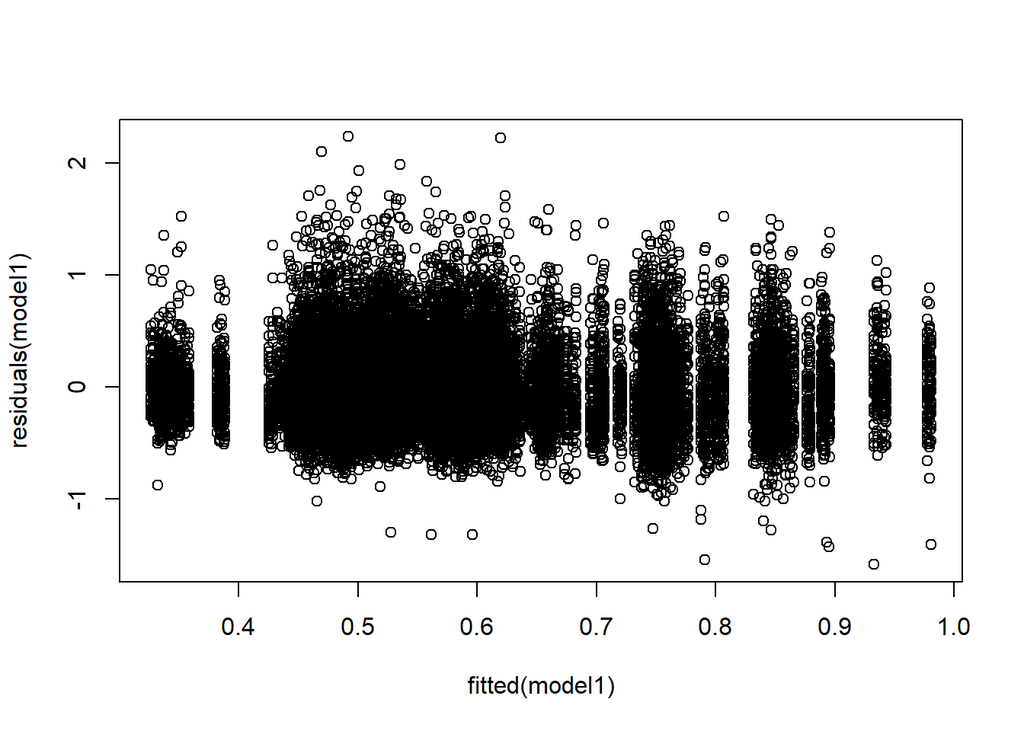

```r
# residual plots for visual inspection
plot(fitted(model1),residuals(model1))
```

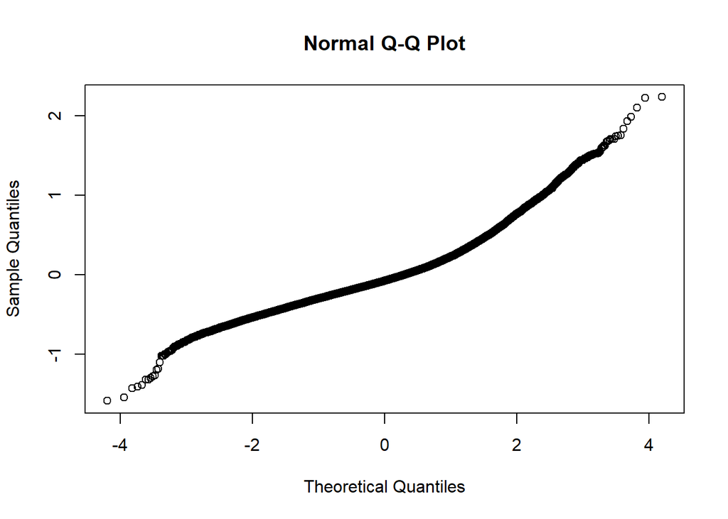

```r
qqnorm(residuals(model1))
```

```r
# get R square
rsq.glmm(model1)
```

```
## $model
## [1] 0.2049899
##
## $fixed
## [1] 0.02246059
##
## $random
## [1] 0.1825293
```

### Onset model

RT2 is modeled as a function of SOA and task relevance. In addition, random intercept and slope of both parameters are taken separately for each subject and duration. We predicted that an interaction between SOA and task relevance such that in both T1 relevance conditions, an negative slope of RT2 is observed as a function of SOA but that the slope is larger (i.e. more negative) for task relevant compared to task irrelevant T1 trials.

```r
# sub analysis restricted to onset
onset_event_table = all_event_table %>% filter(SOA_lock == "onset")

# fit onset model
onset_model_prereg = glmer(RT_aud ~ f_SOA*c_task_relevant +
                       (1*f_SOA*c_task_relevant | sub_id) +
                       (1*f_SOA*c_task_relevant | f_duration),
                     family = Gamma(link="identity"), data = onset_event_table)
```

```
## boundary (singular) fit: see help('isSingular')
```

```r
summary(onset_model_prereg)
```

```
## Generalized linear mixed model fit by maximum likelihood (Laplace
##   Approximation) [glmerMod]
##  Family: Gamma  ( identity )
## Formula: RT_aud ~ f_SOA * c_task_relevant + (1 * f_SOA * c_task_relevant |
##     sub_id) + (1 * f_SOA * c_task_relevant | f_duration)
##    Data: onset_event_table
##
##      AIC      BIC   logLik deviance df.resid
## -12408.1 -12321.9   6215.0 -12430.1    18720
##
## Scaled residuals:
##     Min      1Q  Median      3Q     Max
## -2.4991 -0.6083 -0.2314  0.3185 11.7829
##
## Random effects:
##  Groups     Name        Variance Std.Dev.
##  sub_id     (Intercept) 0.002753 0.05247
##  f_duration (Intercept) 0.000000 0.00000
##  Residual               0.125438 0.35417
## Number of obs: 18731, groups:  sub_id, 21; f_duration, 3
##
## Fixed effects:
##                          Estimate Std. Error t value Pr(>|z|)
## (Intercept)              0.598364   0.030257  19.776  < 2e-16 ***
## f_SOA.L                 -0.085742   0.002582 -33.203  < 2e-16 ***
## f_SOA.Q                  0.012285   0.002554   4.810 1.51e-06 ***
## f_SOA.C                  0.005711   0.002529   2.259   0.0239 *
## c_task_relevant          0.035727   0.002557  13.975  < 2e-16 ***
## f_SOA.L:c_task_relevant -0.010057   0.005159  -1.949   0.0513 .
## f_SOA.Q:c_task_relevant -0.012054   0.005110  -2.359   0.0183 *
## f_SOA.C:c_task_relevant -0.005975   0.005059  -1.181   0.2376
## ---
## Signif. codes:  0 '***' 0.001 '**' 0.01 '*' 0.05 '.' 0.1 ' ' 1
##
## Correlation of Fixed Effects:
##             (Intr) f_SOA.L f_SOA.Q f_SOA.C c_tsk_ f_SOA.L: f_SOA.Q:
## f_SOA.L     -0.006
## f_SOA.Q      0.001 -0.128
## f_SOA.C      0.000  0.014  -0.110
## c_tsk_rlvnt  0.003 -0.013  -0.014   0.000
## f_SOA.L:c__  0.000  0.056  -0.009  -0.008  -0.167
## f_SOA.Q:c__ -0.001 -0.009   0.069  -0.007   0.024 -0.128
## f_SOA.C:c__  0.000 -0.008  -0.007   0.082   0.009  0.015   -0.110
## optimizer (Nelder_Mead) convergence code: 0 (OK)
## boundary (singular) fit: see help('isSingular')
```

```r
# Fit onset model without the effect of duration due to fitting issues:
onset_model_no_dur = glmer(RT_aud ~ f_SOA*c_task_relevant +
                       (1*f_SOA*c_task_relevant | sub_id),
                     family = Gamma(link="identity"), data = onset_event_table)
# Compare the two models to see which is best:
anova(onset_model_no_dur, onset_model_prereg)
```

```
## Data: onset_event_table
## Models:
## onset_model_no_dur: RT_aud ~ f_SOA * c_task_relevant + (1 * f_SOA * c_task_relevant | sub_id)
## onset_model_prereg: RT_aud ~ f_SOA * c_task_relevant + (1 * f_SOA * c_task_relevant | sub_id) + (1 * f_SOA * c_task_relevant | f_duration)
##                    npar    AIC    BIC logLik deviance Chisq Df Pr(>Chisq)
## onset_model_no_dur   10 -12410 -12332   6215   -12430
## onset_model_prereg   11 -12408 -12322   6215   -12430     0  1     0.9999
```

```r
# get chisquare and p values
anova_results <- Anova(onset_model_no_dur)
write.csv(anova_results, file = file.path(save_dir, "Experiment1-onset_mdl_anova.csv"), row.names = TRUE)
anova_results
```

```
## Analysis of Deviance Table (Type II Wald chisquare tests)
##
## Response: RT_aud
##                          Chisq Df Pr(>Chisq)
## f_SOA                 1109.313  3    < 2e-16 ***
## c_task_relevant        192.370  1    < 2e-16 ***
## f_SOA:c_task_relevant   12.817  3    0.00505 **
## ---
## Signif. codes:  0 '***' 0.001 '**' 0.01 '*' 0.05 '.' 0.1 ' ' 1
```

```r
# Post-hoc test: compare RT2 between task relevance condition separately for each SOA to quantify the difference in central stage occupation
# between task relevance conditions
em1 <- emmeans(onset_model_no_dur, "c_task_relevant", by = "f_SOA")
onset_soa_contrasts <- contrast(em1, "pairwise", adjust = "bonferroni")
onset_soa_contrasts
```

```
## f_SOA = 0:
##  contrast
##  (c_task_relevant-0.497163196488787) - c_task_relevant0.502836803511213
##  estimate      SE  df z.ratio p.value
##   -0.0378 0.00571 Inf  -6.623  <.0001
##
## f_SOA = 0.116:
##  contrast
##  (c_task_relevant-0.497163196488787) - c_task_relevant0.502836803511213
##  estimate      SE  df z.ratio p.value
##   -0.0400 0.00527 Inf  -7.588  <.0001
##
## f_SOA = 0.232:
##  contrast
##  (c_task_relevant-0.497163196488787) - c_task_relevant0.502836803511213
##  estimate      SE  df z.ratio p.value
##   -0.0435 0.00482 Inf  -9.036  <.0001
##
## f_SOA = 0.466:
##  contrast
##  (c_task_relevant-0.497163196488787) - c_task_relevant0.502836803511213
##  estimate      SE  df z.ratio p.value
##   -0.0216 0.00458 Inf  -4.723  <.0001
```

```r
# get R square
rsq.glmm(onset_model_no_dur)
```

```
## $model
## [1] 0.2010498
##
## $fixed
## [1] 0.02327252
##
## $random
## [1] 0.1777773
```

### Offset model

RT2 is modeled as a function of SOA, task relevance and T1 duration. The effect of duration was added to account for potential lingering effect of T1 processing on RT2. In addition, random intercept and slope of both parameters are taken separately for each subject. We predicted that no effect of SOA should be observed when the tone was presented relative to the offset of the visual stimulus, as this event is not task relevance and therefore should not be processed by the central stage. We however predicted that if T1 processing last longer than the T1 stimuli duration, an effect of SOA should be observed not because of the offset itself but rather due to the increased temporal interval between T1 onset and T2 onset with increasing SOAs. We expected such an effect could occur for short T1 trials (lasting only 500ms), but not for larger T1 duration. In other words, we predict that if such lingering T1 processing effect occurs, it should decrease with increased T1 duration.

```r
# sub analysis restricted to offset
offset_event_table = all_event_table %>% filter(SOA_lock == "offset")

# fit offset model
offset_model = glmer(RT_aud ~ f_SOA*f_duration*c_task_relevant +
                       (1*f_SOA*f_duration*c_task_relevant | sub_id),
                     family = Gamma(link="identity"), data = offset_event_table)
summary(offset_model)
```

```
## Generalized linear mixed model fit by maximum likelihood (Laplace
##   Approximation) [glmerMod]
##  Family: Gamma  ( identity )
## Formula: RT_aud ~ f_SOA * f_duration * c_task_relevant + (1 * f_SOA *
##     f_duration * c_task_relevant | sub_id)
##    Data: offset_event_table
##
##      AIC      BIC   logLik deviance df.resid
## -16911.4 -16707.7   8481.7 -16963.4    18609
##
## Scaled residuals:
##     Min      1Q  Median      3Q     Max
## -2.3868 -0.5989 -0.1933  0.3386 14.0119
##
## Random effects:
##  Groups   Name        Variance Std.Dev.
##  sub_id   (Intercept) 0.002234 0.04727
##  Residual             0.112291 0.33510
## Number of obs: 18635, groups:  sub_id, 21
##
## Fixed effects:
##                                        Estimate Std. Error t value Pr(>|z|)
## (Intercept)                           5.508e-01  2.871e-02  19.185  < 2e-16 ***
## f_SOA.L                              -1.402e-02  2.240e-03  -6.261 3.83e-10 ***
## f_SOA.Q                               4.244e-03  2.229e-03   1.904 0.056890 .
## f_SOA.C                              -2.807e-03  2.219e-03  -1.265 0.205968
## f_duration.L                          6.464e-03  1.931e-03   3.347 0.000816 ***
## f_duration.Q                         -1.852e-03  1.932e-03  -0.959 0.337707
## c_task_relevant                       4.689e-03  2.229e-03   2.104 0.035404 *
## f_SOA.L:f_duration.L                 -1.579e-02  3.884e-03  -4.067 4.76e-05 ***
## f_SOA.Q:f_duration.L                  3.076e-03  3.859e-03   0.797 0.425486
## f_SOA.C:f_duration.L                  5.685e-03  3.835e-03   1.483 0.138186
## f_SOA.L:f_duration.Q                 -8.251e-03  3.871e-03  -2.131 0.033061 *
## f_SOA.Q:f_duration.Q                  8.052e-03  3.862e-03   2.085 0.037076 *
## f_SOA.C:f_duration.Q                  1.066e-02  3.854e-03   2.767 0.005665 **
## f_SOA.L:c_task_relevant              -1.467e-03  4.477e-03  -0.328 0.743236
## f_SOA.Q:c_task_relevant              -1.727e-03  4.458e-03  -0.388 0.698357
## f_SOA.C:c_task_relevant              -3.909e-03  4.439e-03  -0.881 0.378479
## f_duration.L:c_task_relevant          9.756e-04  3.859e-03   0.253 0.800418
## f_duration.Q:c_task_relevant         -4.774e-03  3.863e-03  -1.236 0.216506
## f_SOA.L:f_duration.L:c_task_relevant -8.764e-03  7.765e-03  -1.129 0.259073
## f_SOA.Q:f_duration.L:c_task_relevant -1.136e-02  7.718e-03  -1.472 0.141030
## f_SOA.C:f_duration.L:c_task_relevant -5.058e-03  7.670e-03  -0.659 0.509666
## f_SOA.L:f_duration.Q:c_task_relevant  4.204e-03  7.743e-03   0.543 0.587148
## f_SOA.Q:f_duration.Q:c_task_relevant -2.403e-06  7.725e-03   0.000 0.999752
## f_SOA.C:f_duration.Q:c_task_relevant -3.224e-03  7.708e-03  -0.418 0.675749
## ---
## Signif. codes:  0 '***' 0.001 '**' 0.01 '*' 0.05 '.' 0.1 ' ' 1
```

```
##
## Correlation matrix not shown by default, as p = 24 > 12.
## Use print(x, correlation=TRUE)  or
##     vcov(x)        if you need it
```

```r
# get chisquare and p values
anova_results <- Anova(offset_model)
write.csv(anova_results, file = file.path(save_dir, "Experiment1-offset_mdl_anova.csv"), row.names = TRUE)
anova_results
```

```
## Analysis of Deviance Table (Type II Wald chisquare tests)
##
## Response: RT_aud
##                                    Chisq Df Pr(>Chisq)
## f_SOA                            42.3131  3  3.443e-09 ***
## f_duration                       10.9301  2   0.004232 **
## c_task_relevant                   4.3401  1   0.037224 *
## f_SOA:f_duration                 35.4364  6  3.547e-06 ***
## f_SOA:c_task_relevant             1.0615  3   0.786370
## f_duration:c_task_relevant        1.6222  2   0.444370
## f_SOA:f_duration:c_task_relevant  4.4901  6   0.610665
## ---
## Signif. codes:  0 '***' 0.001 '**' 0.01 '*' 0.05 '.' 0.1 ' ' 1
```

```r
# get R square
rsq.glmm(offset_model)
```

```
## $model
## [1] 0.2080446
##
## $fixed
## [1] 0.002511831
##
## $random
## [1] 0.2055328
```

```r
# post-hoc bonferroni corrected pairwise comparison
em1 <- emmeans(offset_model, "f_SOA", by = "f_duration")
```

```
## NOTE: Results may be misleading due to involvement in interactions
```

```r
offset_soa_contrasts <- contrast(em1, "pairwise", adjust = "bonferroni")
# Save to file:
write.csv(offset_soa_contrasts, file = file.path(save_dir, "Experiment1-offset_soa_contrasts.csv"), row.names = TRUE)
```

### Control: Post-hoc offset PRP analysis separately for each duration

```r
# =======================================================================
# Short
offset_short_event_table = offset_event_table %>% filter(duration == 0.5)
# Modelling:
offset_short_model = glmer(RT_aud ~ f_SOA*c_task_relevant +
                       (1*f_SOA*c_task_relevant | sub_id),
                     family = Gamma(link="identity"), data = offset_short_event_table)
summary(offset_short_model)
```

```
## Generalized linear mixed model fit by maximum likelihood (Laplace
##   Approximation) [glmerMod]
##  Family: Gamma  ( identity )
## Formula: RT_aud ~ f_SOA * c_task_relevant + (1 * f_SOA * c_task_relevant |
##     sub_id)
##    Data: offset_short_event_table
##
##      AIC      BIC   logLik deviance df.resid
##  -5365.8  -5298.3   2692.9  -5385.8     6281
##
## Scaled residuals:
##     Min      1Q  Median      3Q     Max
## -2.2423 -0.5800 -0.1902  0.3021 12.2757
##
## Random effects:
##  Groups   Name        Variance Std.Dev.
##  sub_id   (Intercept) 0.003191 0.05649
##  Residual             0.126046 0.35503
## Number of obs: 6291, groups:  sub_id, 21
##
## Fixed effects:
##                          Estimate Std. Error t value Pr(>|z|)
## (Intercept)              0.548963   0.030537  17.977   <2e-16 ***
## f_SOA.L                 -0.005374   0.003955  -1.359    0.174
## f_SOA.Q                  0.005429   0.003932   1.381    0.167
## f_SOA.C                 -0.002717   0.003914  -0.694    0.487
## c_task_relevant          0.001753   0.003931   0.446    0.656
## f_SOA.L:c_task_relevant  0.005812   0.007901   0.736    0.462
## f_SOA.Q:c_task_relevant  0.006773   0.007866   0.861    0.389
## f_SOA.C:c_task_relevant -0.001388   0.007826  -0.177    0.859
## ---
## Signif. codes:  0 '***' 0.001 '**' 0.01 '*' 0.05 '.' 0.1 ' ' 1
##
## Correlation of Fixed Effects:
##             (Intr) f_SOA.L f_SOA.Q f_SOA.C c_tsk_ f_SOA.L: f_SOA.Q:
## f_SOA.L     -0.001
## f_SOA.Q      0.001 -0.006
## f_SOA.C      0.000  0.007  -0.004
## c_tsk_rlvnt  0.000  0.006   0.000   0.000
## f_SOA.L:c__  0.000  0.006   0.004   0.001  -0.008
## f_SOA.Q:c__  0.000  0.006   0.006   0.004   0.011 -0.007
## f_SOA.C:c__  0.000  0.000   0.004   0.007  -0.001  0.007   -0.004
```

```r
# Anova
anova_results <- Anova(offset_short_model)
write.csv(anova_results, file = file.path(save_dir, "Experiment1-offset_short_mdl_anova.csv"), row.names = TRUE)
anova_results
```

```
## Analysis of Deviance Table (Type II Wald chisquare tests)
##
## Response: RT_aud
##                        Chisq Df Pr(>Chisq)
## f_SOA                 4.2017  3     0.2405
## c_task_relevant       0.1949  1     0.6588
## f_SOA:c_task_relevant 1.3236  3     0.7235
```

```r
# =======================================================================
# Intermediate
offset_int_event_table = offset_event_table %>% filter(duration == 1.0)
# Modelling:
offset_int_model = glmer(RT_aud ~ f_SOA*c_task_relevant +
                       (1*f_SOA*c_task_relevant | sub_id),
                     family = Gamma(link="identity"), data = offset_int_event_table)
summary(offset_int_model)
```

```
## Generalized linear mixed model fit by maximum likelihood (Laplace
##   Approximation) [glmerMod]
##  Family: Gamma  ( identity )
## Formula: RT_aud ~ f_SOA * c_task_relevant + (1 * f_SOA * c_task_relevant |
##     sub_id)
##    Data: offset_int_event_table
##
##      AIC      BIC   logLik deviance df.resid
##  -5541.4  -5474.0   2780.7  -5561.4     6266
##
## Scaled residuals:
##     Min      1Q  Median      3Q     Max
## -2.1694 -0.6132 -0.1929  0.3682  8.0275
##
## Random effects:
##  Groups   Name        Variance Std.Dev.
##  sub_id   (Intercept) 0.003375 0.05809
##  Residual             0.110619 0.33259
## Number of obs: 6276, groups:  sub_id, 21
##
## Fixed effects:
##                          Estimate Std. Error t value Pr(>|z|)
## (Intercept)              0.562637   0.033688  16.701  < 2e-16 ***
## f_SOA.L                 -0.007293   0.003854  -1.892  0.05847 .
## f_SOA.Q                 -0.002276   0.003849  -0.591  0.55428
## f_SOA.C                 -0.011394   0.003850  -2.959  0.00308 **
## c_task_relevant          0.008610   0.003854   2.234  0.02548 *
## f_SOA.L:c_task_relevant -0.004989   0.007705  -0.648  0.51730
## f_SOA.Q:c_task_relevant -0.001630   0.007701  -0.212  0.83239
## f_SOA.C:c_task_relevant -0.001327   0.007700  -0.172  0.86319
## ---
## Signif. codes:  0 '***' 0.001 '**' 0.01 '*' 0.05 '.' 0.1 ' ' 1
##
## Correlation of Fixed Effects:
##             (Intr) f_SOA.L f_SOA.Q f_SOA.C c_tsk_ f_SOA.L: f_SOA.Q:
## f_SOA.L     -0.001
## f_SOA.Q      0.000 -0.020
## f_SOA.C     -0.001  0.000   0.012
## c_tsk_rlvnt  0.001 -0.005  -0.005  -0.003
## f_SOA.L:c__  0.000  0.010  -0.005  -0.004  -0.009
## f_SOA.Q:c__  0.000 -0.005   0.014  -0.001   0.000 -0.021
## f_SOA.C:c__  0.000 -0.003  -0.001   0.019  -0.022  0.000    0.013
```

```r
# Anova
anova_results <- Anova(offset_int_model)
write.csv(anova_results, file = file.path(save_dir, "Experiment1-offset_int_mdl_anova.csv"), row.names = TRUE)
anova_results
```

```
## Analysis of Deviance Table (Type II Wald chisquare tests)
##
## Response: RT_aud
##                         Chisq Df Pr(>Chisq)
## f_SOA                 12.6683  3   0.005412 **
## c_task_relevant        4.9518  1   0.026064 *
## f_SOA:c_task_relevant  0.4986  3   0.919199
## ---
## Signif. codes:  0 '***' 0.001 '**' 0.01 '*' 0.05 '.' 0.1 ' ' 1
```

```r
# =======================================================================
# Long
offset_long_event_table = offset_event_table %>% filter(duration == 1.5)
# Modelling:
offset_long_model = glmer(RT_aud ~ f_SOA*c_task_relevant +
                       (1*f_SOA*c_task_relevant | sub_id),
                     family = Gamma(link="identity"), data = offset_long_event_table)
summary(offset_long_model)
```

```
## Generalized linear mixed model fit by maximum likelihood (Laplace
##   Approximation) [glmerMod]
##  Family: Gamma  ( identity )
## Formula: RT_aud ~ f_SOA * c_task_relevant + (1 * f_SOA * c_task_relevant |
##     sub_id)
##    Data: offset_long_event_table
##
##      AIC      BIC   logLik deviance df.resid
##  -6051.6  -5984.5   3035.8  -6071.6     6058
##
## Scaled residuals:
##     Min      1Q  Median      3Q     Max
## -2.0882 -0.6106 -0.1892  0.3657  8.4629
##
## Random effects:
##  Groups   Name        Variance Std.Dev.
##  sub_id   (Intercept) 0.002274 0.04768
##  Residual             0.098804 0.31433
## Number of obs: 6068, groups:  sub_id, 21
##
## Fixed effects:
##                          Estimate Std. Error t value Pr(>|z|)
## (Intercept)              0.556539   0.027780  20.034  < 2e-16 ***
## f_SOA.L                 -0.029304   0.003763  -7.788 6.82e-15 ***
## f_SOA.Q                  0.009798   0.003731   2.626  0.00864 **
## f_SOA.C                  0.005619   0.003700   1.519  0.12879
## c_task_relevant          0.003077   0.003729   0.825  0.40931
## f_SOA.L:c_task_relevant -0.005284   0.007518  -0.703  0.48215
## f_SOA.Q:c_task_relevant -0.009350   0.007457  -1.254  0.20989
## f_SOA.C:c_task_relevant -0.009687   0.007403  -1.309  0.19066
## ---
## Signif. codes:  0 '***' 0.001 '**' 0.01 '*' 0.05 '.' 0.1 ' ' 1
##
## Correlation of Fixed Effects:
##             (Intr) f_SOA.L f_SOA.Q f_SOA.C c_tsk_ f_SOA.L: f_SOA.Q:
## f_SOA.L     -0.004
## f_SOA.Q      0.001 -0.044
## f_SOA.C      0.001  0.012  -0.049
## c_tsk_rlvnt  0.001 -0.009  -0.012  -0.009
## f_SOA.L:c__ -0.001  0.000  -0.013  -0.007  -0.064
## f_SOA.Q:c__ -0.001 -0.013   0.010   0.002   0.019 -0.045
## f_SOA.C:c__  0.000 -0.007   0.002   0.019   0.012  0.011   -0.049
```

```r
# Anova
anova_results <- Anova(offset_long_model)
write.csv(anova_results, file = file.path(save_dir, "Experiment1-offset_long_mdl_anova.csv"), row.names = TRUE)
anova_results
```

```
## Analysis of Deviance Table (Type II Wald chisquare tests)
##
## Response: RT_aud
##                         Chisq Df Pr(>Chisq)
## f_SOA                 69.4407  3  5.624e-15 ***
## c_task_relevant        0.6739  1     0.4117
## f_SOA:c_task_relevant  4.0118  3     0.2602
## ---
## Signif. codes:  0 '***' 0.001 '**' 0.01 '*' 0.05 '.' 0.1 ' ' 1
```

```r
# Comparing RT2 between all pairs of SOAs separately for each T1 duration conditions:
em1 <- emmeans(offset_model, "f_SOA", by = "f_duration")
```

```
## NOTE: Results may be misleading due to involvement in interactions
```

```r
offset_soa_contrasts <- contrast(em1, "pairwise", adjust = "bonferroni")
onset_soa_contrasts
```

```
## f_SOA = 0:
##  contrast
##  (c_task_relevant-0.497163196488787) - c_task_relevant0.502836803511213
##  estimate      SE  df z.ratio p.value
##   -0.0378 0.00571 Inf  -6.623  <.0001
##
## f_SOA = 0.116:
##  contrast
##  (c_task_relevant-0.497163196488787) - c_task_relevant0.502836803511213
##  estimate      SE  df z.ratio p.value
##   -0.0400 0.00527 Inf  -7.588  <.0001
##
## f_SOA = 0.232:
##  contrast
##  (c_task_relevant-0.497163196488787) - c_task_relevant0.502836803511213
##  estimate      SE  df z.ratio p.value
##   -0.0435 0.00482 Inf  -9.036  <.0001
##
## f_SOA = 0.466:
##  contrast
##  (c_task_relevant-0.497163196488787) - c_task_relevant0.502836803511213
##  estimate      SE  df z.ratio p.value
##   -0.0216 0.00458 Inf  -4.723  <.0001
```

### Control: Comparing onset locked 466ms SOA vs long trials 0ms SOA

Not pre-registered: We observed a PRP effect at stimulus offset especially for long trials. This may indicate that the disappearance of the visual stimulus in the long trials was indeed processed by the central stage and accordingly induced a PRP effect when T2 was presented in close succession to that event. Alternatively, the decrease in RT2 with increased SOA might reflect a facilitation of T2 processing at increased SOA, due to the increased probability of the event occuring at large SOAs (hazard rate). If that is the case RT2 should be at baseline at SOA=0 and fastest at SOA=0.466s. We do not have a clean baseline in our study. However, in the onset trials (where a clear PRP effect is observed), RT2 at SOA = 0.466 should be the closest to it. It is likely that the interference period was not completely over by 0.466ms, in which case, RT2 would be higher compared to baseline. If we observe that RT2 in SOA=0s in offset locked long trials is larger than at SOA=0.466ms onset locked trials, then this implies that RT2 in the offset locked long trials is larger than a data point that is itself larger than baseline. In that case, the decrease of RT2 with increased SOA in offset locked long trials does not reflect a facilitation at larger SOAs but rather a delaying at short SOAs, consistent with a PRP effect.

```r
# Extract the two conditions of interest:
comp_tbl = all_event_table %>% filter((duration == 1.5 & SOA == 0 & SOA_lock == 'offset') | (SOA == 0.466 & SOA_lock == 'onset'))
# with duration, category and pitch as random effects
comparison_mdl = glmer(RT_aud ~ SOA_lock +
                     (1*SOA_lock | sub_id),
                   family=Gamma(link="identity"), data=comp_tbl)
summary(comparison_mdl)
```

```
## Generalized linear mixed model fit by maximum likelihood (Laplace
##   Approximation) [glmerMod]
##  Family: Gamma  ( identity )
## Formula: RT_aud ~ SOA_lock + (1 * SOA_lock | sub_id)
##    Data: comp_tbl
##
##      AIC      BIC   logLik deviance df.resid
##  -5099.4  -5072.4   2553.7  -5107.4     6253
##
## Scaled residuals:
##     Min      1Q  Median      3Q     Max
## -1.9645 -0.5956 -0.2092  0.3093 10.2248
##
## Random effects:
##  Groups   Name        Variance Std.Dev.
##  sub_id   (Intercept) 0.003226 0.0568
##  Residual             0.125376 0.3541
## Number of obs: 6257, groups:  sub_id, 21
##
## Fixed effects:
##                Estimate Std. Error t value Pr(>|z|)
## (Intercept)    0.581283   0.030959  18.776  < 2e-16 ***
## SOA_lockonset -0.030196   0.004852  -6.223 4.87e-10 ***
## ---
## Signif. codes:  0 '***' 0.001 '**' 0.01 '*' 0.05 '.' 0.1 ' ' 1
##
## Correlation of Fixed Effects:
##             (Intr)
## SOA_locknst -0.122
```

```r
# get chisquare and p values
Anova(comparison_mdl)
```

```
## Analysis of Deviance Table (Type II Wald chisquare tests)
##
## Response: RT_aud
##          Chisq Df Pr(>Chisq)
## SOA_lock 38.73  1  4.867e-10 ***
## ---
## Signif. codes:  0 '***' 0.001 '**' 0.01 '*' 0.05 '.' 0.1 ' ' 1
```

```r
em1 <- emmeans(comparison_mdl, "SOA_lock")
onset_vs_long_soa_contrast <- contrast(em1, "pairwise", adjust = "bonferroni")
# Save to file:
write.csv(onset_vs_long_soa_contrast, file = file.path(save_dir, "Experiment1-offset_vs_onset_soa_contrasts.csv"), row.names = TRUE)
```

### Control: control model

```r
# with duration, category and pitch as random effects
ctr_model = glmer(RT_aud ~ f_SOA*c_is_onset*c_task_relevant +
                     (1*f_SOA*c_is_onset*c_task_relevant | sub_id) +
                     (1*f_SOA*c_is_onset*c_task_relevant | f_duration) +
                     (1*f_SOA*c_is_onset*c_task_relevant | c_pitch) +
                     (1*f_SOA*c_is_onset*c_task_relevant | category),
                   family=Gamma(link="identity"), data=all_event_table)
summary(ctr_model)
```

```
## Generalized linear mixed model fit by maximum likelihood (Laplace
##   Approximation) [glmerMod]
##  Family: Gamma  ( identity )
## Formula: RT_aud ~ f_SOA * c_is_onset * c_task_relevant + (1 * f_SOA *
##     c_is_onset * c_task_relevant | sub_id) + (1 * f_SOA * c_is_onset *
##     c_task_relevant | f_duration) + (1 * f_SOA * c_is_onset *
##     c_task_relevant | c_pitch) + (1 * f_SOA * c_is_onset * c_task_relevant |
##     category)
##    Data: all_event_table
##
##      AIC      BIC   logLik deviance df.resid
## -29056.8 -28877.7  14549.4 -29098.8    37345
##
## Scaled residuals:
##     Min      1Q  Median      3Q     Max
## -2.5522 -0.6050 -0.2080  0.3251 12.1449
##
## Random effects:
##  Groups     Name        Variance  Std.Dev.
##  sub_id     (Intercept) 2.162e-03 0.046496
##  category   (Intercept) 1.151e-05 0.003393
##  f_duration (Intercept) 4.190e-06 0.002047
##  c_pitch    (Intercept) 2.716e-05 0.005212
##  Residual               1.197e-01 0.346006
## Number of obs: 37366, groups:
## sub_id, 21; category, 4; f_duration, 3; c_pitch, 2
##
## Fixed effects:
##                                     Estimate Std. Error t value Pr(>|z|)
## (Intercept)                         0.572353   0.030668  18.663  < 2e-16 ***
## f_SOA.L                            -0.049973   0.001714 -29.155  < 2e-16 ***
## f_SOA.Q                             0.008202   0.001701   4.822 1.42e-06 ***
## f_SOA.C                             0.001360   0.001688   0.805   0.4207
## c_is_onset                          0.047640   0.001704  27.954  < 2e-16 ***
## c_task_relevant                     0.020503   0.001702  12.049  < 2e-16 ***
## f_SOA.L:c_is_onset                 -0.072981   0.003428 -21.292  < 2e-16 ***
## f_SOA.Q:c_is_onset                  0.007757   0.003401   2.281   0.0226 *
## f_SOA.C:c_is_onset                  0.008404   0.003376   2.489   0.0128 *
## f_SOA.L:c_task_relevant            -0.005677   0.003427  -1.656   0.0976 .
## f_SOA.Q:c_task_relevant            -0.006863   0.003403  -2.017   0.0437 *
## f_SOA.C:c_task_relevant            -0.005138   0.003378  -1.521   0.1283
## c_is_onset:c_task_relevant          0.031260   0.003403   9.187  < 2e-16 ***
## f_SOA.L:c_is_onset:c_task_relevant -0.007618   0.006853  -1.112   0.2663
## f_SOA.Q:c_is_onset:c_task_relevant -0.010585   0.006803  -1.556   0.1197
## f_SOA.C:c_is_onset:c_task_relevant -0.002955   0.006754  -0.438   0.6617
## ---
## Signif. codes:  0 '***' 0.001 '**' 0.01 '*' 0.05 '.' 0.1 ' ' 1
```

```
##
## Correlation matrix not shown by default, as p = 16 > 12.
## Use print(x, correlation=TRUE)  or
##     vcov(x)        if you need it
```

```r
# get chisquare and p values
Anova(ctr_model)
```

```
## Analysis of Deviance Table (Type II Wald chisquare tests)
##
## Response: RT_aud
##                                     Chisq Df Pr(>Chisq)
## f_SOA                            737.0845  3    < 2e-16 ***
## c_is_onset                       648.5136  1    < 2e-16 ***
## c_task_relevant                  125.0116  1    < 2e-16 ***
## f_SOA:c_is_onset                 460.9269  3    < 2e-16 ***
## f_SOA:c_task_relevant              9.8428  3    0.01995 *
## c_is_onset:c_task_relevant        83.5374  1    < 2e-16 ***
## f_SOA:c_is_onset:c_task_relevant   4.2493  3    0.23577
## ---
## Signif. codes:  0 '***' 0.001 '**' 0.01 '*' 0.05 '.' 0.1 ' ' 1
```

```r
# get R square
rsq.glmm(ctr_model)
```

```
## $model
## [1] 0.2056086
##
## $fixed
## [1] 0.02246059
##
## $random
## [1] 0.183148
```

```r
# compare control_model with main model
anova(model1, ctr_model)
```

```
## Data: all_event_table
## Models:
## model1: RT_aud ~ f_SOA * c_is_onset * c_task_relevant + (1 * f_SOA * c_is_onset * c_task_relevant | sub_id) + (1 * f_SOA * c_is_onset * c_task_relevant | f_duration)
## ctr_model: RT_aud ~ f_SOA * c_is_onset * c_task_relevant + (1 * f_SOA * c_is_onset * c_task_relevant | sub_id) + (1 * f_SOA * c_is_onset * c_task_relevant | f_duration) + (1 * f_SOA * c_is_onset * c_task_relevant | c_pitch) + (1 * f_SOA * c_is_onset * c_task_relevant | category)
##           npar    AIC    BIC logLik deviance  Chisq Df Pr(>Chisq)
## model1      19 -28961 -28798  14499   -28999
## ctr_model   21 -29057 -28878  14549   -29099 100.33  2  < 2.2e-16 ***
## ---
## Signif. codes:  0 '***' 0.001 '**' 0.01 '*' 0.05 '.' 0.1 ' ' 1
```

### effect size of PRP

PRP effect magnitude: Difference in ms between short SOA and longest SOA for certain condition PRP effect size: Cohen’s D effect size for the same contrast

```r
# initialize varibales
effect_size_table = matrix(ncol = 6, nrow = 5)
rownames(effect_size_table) = c("Mean_SOA0", "Mean_SOA466", "PRP_size", "joined_SD", "Cohensd")
colnames(effect_size_table) = c("target", "non_target_onset", "irrelevant_onset", "offset_short", "offset_intermediate", "offset_long")
# mean of SOA = 0
effect_size_table[1, ] = c(mean(target_event_table %>% filter(SOA == 0 & SOA_lock == 'onset' & task_relevance == 'target') %>% pull(RT_aud), na.rm = TRUE),
                           mean(target_event_table %>% filter(SOA == 0 & SOA_lock == 'onset' & task_relevance == 'non-target') %>% pull(RT_aud), na.rm = TRUE),
                           mean(target_event_table %>% filter(SOA == 0 & SOA_lock == 'onset' & task_relevance == 'irrelevant') %>% pull(RT_aud), na.rm = TRUE),
                           mean(all_event_table %>% filter(SOA == 0 & SOA_lock == 'offset' & duration == 0.5) %>% pull(RT_aud), na.rm = TRUE),
                           mean(all_event_table %>% filter(SOA == 0 & SOA_lock == 'offset' & duration == 1) %>% pull(RT_aud), na.rm = TRUE),
                           mean(all_event_table %>% filter(SOA == 0 & SOA_lock == 'offset' & duration == 1.5) %>% pull(RT_aud), na.rm = TRUE))
# mean of SOA = 466
effect_size_table[2, ] = c(mean(target_event_table %>% filter(SOA == 0.466 & SOA_lock == 'offset' & task_relevance == 'target' & duration == 1.5) %>% pull(RT_aud), na.rm = TRUE),
                           mean(target_event_table %>% filter(SOA == 0.466 & SOA_lock == 'onset' & task_relevance == 'non-target') %>% pull(RT_aud), na.rm = TRUE),
                           mean(target_event_table %>% filter(SOA == 0.466 & SOA_lock == 'onset' & task_relevance == 'irrelevant') %>% pull(RT_aud), na.rm = TRUE),
                           mean(all_event_table %>% filter(SOA == 0.466 & SOA_lock == 'offset' &  duration == 0.5) %>% pull(RT_aud), na.rm = TRUE),
                           mean(all_event_table %>% filter(SOA == 0.466 & SOA_lock == 'offset' &  duration == 1) %>% pull(RT_aud), na.rm = TRUE),
                           mean(all_event_table %>% filter(SOA == 0.466 & SOA_lock == 'offset' &  duration == 1.5) %>% pull(RT_aud), na.rm = TRUE))
# PRP size
effect_size_table[3, ] = effect_size_table[1, ] - effect_size_table[2, ]
# joined SD
effect_size_table[4, ] = c(sd(c(target_event_table %>% filter(SOA == 0 & SOA_lock == 'onset' & task_relevance == 'target') %>% pull(RT_aud),target_event_table %>% filter(SOA == 0.466 & SOA_lock == 'offset' & task_relevance == 'target' & duration == 1.5) %>% pull(RT_aud))),
                           sd(c(target_event_table %>% filter(SOA == 0 & SOA_lock == 'onset' & task_relevance == 'non-target') %>% pull(RT_aud), target_event_table %>% filter(SOA == 0.466 & SOA_lock == 'onset' & task_relevance == 'non-target') %>% pull(RT_aud))),
                           sd(c(target_event_table %>% filter(SOA == 0 & SOA_lock == 'onset' & task_relevance == 'irrelevant') %>% pull(RT_aud), target_event_table %>% filter(SOA == 0.466 & SOA_lock == 'onset' & task_relevance == 'irrelevant') %>% pull(RT_aud))),
                           sd(c(all_event_table %>% filter(SOA == 0 & SOA_lock == 'offset' & duration == 0.5) %>% pull(RT_aud), all_event_table %>% filter(SOA == 0.466 & SOA_lock == 'offset' &  duration == 0.5) %>% pull(RT_aud))),
                           sd(c(all_event_table %>% filter(SOA == 0 & SOA_lock == 'offset' & duration == 1) %>% pull(RT_aud), all_event_table %>% filter(SOA == 0.466 & SOA_lock == 'offset' &  duration == 1) %>% pull(RT_aud))),
                           sd(c(all_event_table %>% filter(SOA == 0 & SOA_lock == 'offset' & duration == 1.5) %>% pull(RT_aud), all_event_table %>% filter(SOA == 0.466 & SOA_lock == 'offset' &  duration == 1.5) %>% pull(RT_aud))))

# cohens d
effect_size_table[5, ] = (effect_size_table[1, ] - effect_size_table[2, ])/effect_size_table[4, ]

# Save the effect size table to file:
write.csv(effect_size_table, file = file.path(save_dir, "Experiment1-effect_sizes.csv"), row.names = TRUE)
```

# Experiment 2

As experiment 1 but with introspective ratings of decision time for both tasks (called iRT_aud and iRT_vis)

## Experiment 2 preprocessing:

### loading files for experiment 2

```r
# details of subjects
subNums2 = c(105, 106, 108, 109, 110, 113, 114, 115, 116, 118) # 101 excluded, 122 is the same as participant 116 from experiment one
n2 = length(subNums2)
sessions2 = c(2,3)
Lab_ID = 'SX'

# experiment 2 will be refered to as task 'introspection'
task = 'introspection'

# initialize loop variables
count = 0
sub_ids = NaN
table_size = 1:n2*2

# loading the files

# loop through subject and session numbers
for (subNum in subNums2){
  for (ses in sessions2){

    count = count + 1
    sub_ids[count] = paste0(Lab_ID, subNum)

    # make folder and file name
    sub_folder = paste0('sub-', Lab_ID, subNum)
    ses_folder = paste0('ses-', ses)
    file_name = paste0(sub_folder, '_', ses_folder, '_run-all_task-', task,'_events.csv')

    # make file directory
    file = file.path(bids_root, sub_folder, ses_folder, 'beh', file_name)

    # load file
    event_table2 = read.csv(file)

    # store table dimensions
    table_size[count] = dim(event_table2 %>% filter(task_relevance != 'target'))[1]

    # make format consistent
    if ('X' %in% colnames(event_table2))
    {event_table2$X <- NULL}

    colnames(event_table2)[which(names(event_table2) == "has_repsonse_vis")] <- "has_response_vis"
    colnames(event_table2)[which(names(event_table2) == "trial_repsonse_vis")] <- "trial_response_vis"

    # add subject number and session column
    event_table2 = event_table2 %>% mutate(sub_num = subNum)
    event_table2 = event_table2 %>% mutate(ses = ses)

    # z-score of iRT_vis and iRT_aud
    event_table2 = event_table2 %>% mutate(z_iRT_vis = (iRT_vis-mean(iRT_vis))/sd(iRT_vis))
    event_table2 = event_table2 %>% mutate(z_iRT_aud = (iRT_aud-mean(iRT_aud))/sd(iRT_aud))

    # z-score of RT_vis and RTaud
    event_table2 = event_table2 %>% mutate(z_RT_vis = (RT_vis-mean(RT_vis, na.rm = TRUE))/sd(RT_vis, na.rm = TRUE))
    event_table2 = event_table2 %>% mutate(z_RT_aud = (RT_aud-mean(RT_aud, na.rm = TRUE))/sd(RT_aud, na.rm = TRUE))

    # concatenate the tables
    if ( exists('all_event_table2')){
      all_event_table2 = rbind(all_event_table2, event_table2)
    } else {
      all_event_table2 = event_table2
    }
  }}

# 116 and 122 are the same person - should have the same id
all_event_table2 = all_event_table2 %>% mutate(sub_num = ifelse(sub_num == 122, 116, sub_num))
all_event_table2 = all_event_table2 %>% mutate(sub_id = ifelse(sub_id == 'SX122','SX116', sub_id))

# Create the directory to store the results:
save_dir <- file.path(bids_root, "derivatives", "beh", "introspection")

# Create the directory if it doesn't exist
if (!file.exists(save_dir)) {
  dir.create(save_dir, recursive = TRUE)
}
```

### apply trial exclusion

```r
# store table without exclusion
raw_event_table2 = all_event_table2

# # remove false alarms
all_event_table2 = all_event_table2[all_event_table2$trial_response_vis != 'fa', ]

# make iRT of 0 a 1 (zeros cause errors in GLMM with gamma family)
all_event_table2$iRT_vis[all_event_table2$iRT_vis == 0] = 1
all_event_table2$iRT_aud[all_event_table2$iRT_aud == 0] = 1

# # remove RT < 100 ms
all_event_table2 = all_event_table2[all_event_table2$RT_aud > 0.1, ]

# remove incorrect auditory responses
all_event_table2 = all_event_table2[all_event_table2$trial_accuracy_aud == 1, ]

# remove NaNs from auditory responses
all_event_table2 = all_event_table2[!is.na(all_event_table2$RT_aud), ]

# store table with targets
target_event_table2 = all_event_table2

# remove target trials from all_event_table
all_event_table2 = all_event_table2[all_event_table2$task_relevance != 'target', ]
```

### transfrom data

Variables for the glmm: RT – raw (gamma identity link function) SOA – ordinal onset/offset – binary, numeric, centered task-relevance – binary, numeric, centered duration – ordinal pitch – binary, numeric, centered category – nominal ”

```r
# add log transformed column
all_event_table2 = all_event_table2 %>% mutate(log_RT_aud = log(RT_aud))

# make task relevance and SOA lock numeric
all_event_table2 = all_event_table2 %>% mutate(is_task_relevant = ifelse(task_relevance == 'non-target',1,0))
all_event_table2 = all_event_table2 %>% mutate(is_onset = ifelse(SOA_lock == 'onset',1,0))

# make SOA and duration factors
all_event_table2 = all_event_table2 %>% mutate(f_SOA = factor(SOA, ordered = TRUE, levels = c("0", "0.232", "0.466")))
all_event_table2 = all_event_table2 %>% mutate(f_duration = factor(duration, ordered = TRUE, levels = c("0.5", "1", "1.5")))

# center variables
all_event_table2 = all_event_table2 %>% mutate(c_task_relevant = is_task_relevant - mean(is_task_relevant))
all_event_table2 = all_event_table2 %>% mutate(c_is_onset = is_onset - mean(is_onset))
all_event_table2 = all_event_table2 %>% mutate(c_SOA = SOA - mean(SOA))
all_event_table2 = all_event_table2 %>% mutate(c_duration = duration - mean(duration))
all_event_table2 = all_event_table2 %>% mutate(c_iRT_vis = (iRT_vis - mean(iRT_vis))/1000)
all_event_table2 = all_event_table2 %>% mutate(c_pitch = (pitch-1050)/100) # makes pitches 0.5 for high and -0.5 for low
```

### test exclusion criteria

```r
# after trials removal
print('number of onset trials after trial removal (incl: targets)')
```

```
## [1] "number of onset trials after trial removal (incl: targets)"
```

```r
sum(target_event_table2$SOA_lock == 'onset')
```

```
## [1] 4401
```

```r
print('number of offset trials after trial removal (incl: targets)')
```

```
## [1] "number of offset trials after trial removal (incl: targets)"
```

```r
sum(target_event_table2$SOA_lock == 'offset')
```

```
## [1] 4408
```

```r
# before
print('number of onset trials before trial removal (incl: targets)')
```

```
## [1] "number of onset trials before trial removal (incl: targets)"
```

```r
sum(raw_event_table2$SOA_lock == 'onset')
```

```
## [1] 4786
```

```r
print('number of offset trials after trial removal (incl: targets)')
```

```
## [1] "number of offset trials after trial removal (incl: targets)"
```

```r
sum(raw_event_table2$SOA_lock == 'offset')
```

```
## [1] 4798
```

```r
# difference
print('number of onset trials removed (excl: targets)')
```

```
## [1] "number of onset trials removed (excl: targets)"
```

```r
sum(raw_event_table2$SOA_lock == 'onset' & raw_event_table2$task_relevance != 'target') - sum(all_event_table2$SOA_lock == 'onset')
```

```
## [1] 321
```

```r
print('number of offset trials removed (excl: targets)')
```

```
## [1] "number of offset trials removed (excl: targets)"
```

```r
sum(raw_event_table2$SOA_lock == 'offset' & raw_event_table2$task_relevance != 'target') - sum(all_event_table2$SOA_lock == 'offset')
```

```
## [1] 315
```

```r
# relative trial removal w/o targets
print('perceptage of onset trials removed (excl: targets)')
```

```
## [1] "perceptage of onset trials removed (excl: targets)"
```

```r
(sum(raw_event_table2$SOA_lock == 'onset' & raw_event_table2$task_relevance != 'target') - sum(all_event_table2$SOA_lock == 'onset'))/sum(raw_event_table2$SOA_lock == 'onset' & raw_event_table2$task_relevance != 'target')
```

```
## [1] 0.07430556
```

```r
print('perceptage of offset trials removed (excl: targets)')
```

```
## [1] "perceptage of offset trials removed (excl: targets)"
```

```r
(sum(raw_event_table2$SOA_lock == 'offset' & raw_event_table2$task_relevance != 'target') - sum(all_event_table2$SOA_lock == 'offset'))/sum(raw_event_table2$SOA_lock == 'offset' & raw_event_table2$task_relevance != 'target')
```

```
## [1] 0.07291667
```

```r
# relative trial removal targets
print('perceptage of onset target trials removed')
```

```
## [1] "perceptage of onset target trials removed"
```

```r
(sum(raw_event_table2$SOA_lock == 'onset' & raw_event_table2$task_relevance == 'target') - sum(target_event_table2$SOA_lock == 'onset' & target_event_table2$task_relevance == 'target'))/sum(raw_event_table2$SOA_lock == 'onset' & raw_event_table2$task_relevance == 'target')
```

```
## [1] 0.1373391
```

```r
print('perceptage of offset target trials removed')
```

```
## [1] "perceptage of offset target trials removed"
```

```r
(sum(raw_event_table2$SOA_lock == 'offset' & raw_event_table2$task_relevance == 'target') - sum(target_event_table2$SOA_lock == 'offset' & target_event_table2$task_relevance == 'target'))/sum(raw_event_table2$SOA_lock == 'offset' & raw_event_table2$task_relevance == 'target')
```

```
## [1] 0.1569038
```

### performance experiment 2

Compute the performance for T1 and T2 in the second experiment.

```r
perf2 = data.frame(matrix(ncol = 0, nrow = 1))
perf2$sub_num = 'NaN'
perf2$hits = NaN
perf2$misses = NaN
perf2$crs = NaN
perf2$fas = NaN
perf2$hit_rate = NaN
perf2$fa_rate = NaN
perf2$aud_acc = NaN
perf2$RT_aud = NaN
perf2$RT_vis = NaN
perf2$RT_aud_raw = NaN
perf2$RT_vis_raw = NaN
perf2 = perf2[-c(1), ]

for (sub_num in subNums2) {
  perf2 = perf2 %>% add_row(sub_num = as.character(sub_num),
                          hits = sum(raw_event_table2$trial_response_vis =='hit' & raw_event_table2$sub_num == sub_num),
                          misses = sum(raw_event_table2$trial_response_vis =='miss' & raw_event_table2$sub_num == sub_num),
                          crs = sum(raw_event_table2$trial_response_vis =='cr' & raw_event_table2$sub_num == sub_num),
                          fas = sum(raw_event_table2$trial_response_vis =='fa' & raw_event_table2$sub_num == sub_num),
                          hit_rate = hits/(hits+misses)*100,
                          fa_rate = fas/(fas+crs)*100,
                          aud_acc = mean(raw_event_table2$trial_accuracy_aud[raw_event_table2$sub_num == sub_num], na.rm = TRUE)*100,
                          RT_aud = mean(target_event_table2$RT_aud[target_event_table2$sub_num == sub_num], na.rm = TRUE)*1000,
                          RT_vis = mean(target_event_table2$RT_vis[target_event_table2$sub_num == sub_num], na.rm = TRUE)*1000,
                          RT_aud_raw = mean(raw_event_table2$RT_aud[raw_event_table2$sub_num == sub_num], na.rm = TRUE)*1000,
                          RT_vis_raw = mean(raw_event_table2$RT_vis[raw_event_table2$sub_num == sub_num], na.rm = TRUE)*1000)
}

# transfer hit rate and false alarm rate into accuracy
perf2 = perf2 %>% mutate(vis_acc = (hits + crs)/(hits + misses + crs + fas)*100)

# add mean and SD
perf2 = perf2 %>% add_row(sub_num = 'mean',
                        hits = mean(perf2$hits),
                        misses = mean(perf2$misses),
                        crs = mean(perf2$crs),
                        fas = mean(perf2$fas),
                        hit_rate = mean(perf2$hit_rate),
                        fa_rate = mean(perf2$fa_rate),
                        aud_acc = mean(perf2$aud_acc),
                        vis_acc = mean(perf2$vis_acc),
                        RT_aud = mean(perf2$RT_aud),
                        RT_vis = mean(perf2$RT_vis),
                        RT_aud_raw = mean(perf2$RT_aud_raw),
                        RT_vis_raw = mean(perf2$RT_vis_raw))

perf2 = perf2 %>% add_row(sub_num = 'sd',
                        hits = sd(perf2$hits[1:n2]),
                        misses = sd(perf2$misses[1:n2]),
                        crs = sd(perf2$crs[1:n2]),
                        fas = sd(perf2$fas[1:n2]),
                        hit_rate = sd(perf2$hit_rate[1:n2]),
                        fa_rate = sd(perf2$fa_rate[1:n2]),
                        aud_acc = sd(perf2$aud_acc[1:n2]),
                        vis_acc = sd(perf2$vis_acc[1:n2]),
                        RT_aud = sd(perf2$RT_aud[1:n2]),
                        RT_vis = sd(perf2$RT_vis[1:n2]),
                        RT_aud_raw = sd(perf2$RT_aud_raw[1:n2]),
                        RT_vis_raw = sd(perf2$RT_vis_raw[1:n2]))

# Save performances to file:
write.csv(perf2, file = file.path(save_dir, "Experiment2-performances.csv"), row.names = TRUE)

# percentage of underestimation in RTaud
underest_RTaud = mean(all_event_table2$iRT_aud)/mean(all_event_table2$RT_aud*1000)
```

## Experiment 2 analysis:

### RT2 analysis:

#### Full, Onset and offset models:

Generalized linear mixed effect model (GLMM) fixed effects: SOA (ordinal), SOA-Lock (as c_is_onset, numeric, centered), Task-relevance (as is relevant, numeric, centered) random effects: Subject ID, Duration (ordinal) GLMMs as in section “glmm1_epx1”, “onset_PRP1”, and “offset_PRP1” but with data from second experiment

```r
# ======================================================================
# Full model:
model_exp2 = glmer(RT_aud ~ f_SOA*c_is_onset*c_task_relevant +
                     (1*f_SOA*c_is_onset*c_task_relevant | sub_id)+
                     (1*f_SOA*c_is_onset*c_task_relevant | f_duration),
               family=Gamma(link="identity"), data=all_event_table2)
summary(model_exp2)
```

```
## Generalized linear mixed model fit by maximum likelihood (Laplace
##   Approximation) [glmerMod]
##  Family: Gamma  ( identity )
## Formula: RT_aud ~ f_SOA * c_is_onset * c_task_relevant + (1 * f_SOA *
##     c_is_onset * c_task_relevant | sub_id) + (1 * f_SOA * c_is_onset *
##     c_task_relevant | f_duration)
##    Data: all_event_table2
##
##      AIC      BIC   logLik deviance df.resid
##  -4786.7  -4681.9   2408.3  -4816.7     7989
##
## Scaled residuals:
##     Min      1Q  Median      3Q     Max
## -1.6590 -0.5813 -0.2202  0.2732 10.2713
##
## Random effects:
##  Groups     Name        Variance  Std.Dev.
##  sub_id     (Intercept) 1.244e-03 0.035269
##  f_duration (Intercept) 4.271e-05 0.006535
##  Residual               1.297e-01 0.360186
## Number of obs: 8004, groups:  sub_id, 10; f_duration, 3
##
## Fixed effects:
##                                      Estimate Std. Error t value Pr(>|z|)
## (Intercept)                         0.6164248  0.0283276  21.761  < 2e-16 ***
## f_SOA.L                            -0.0690071  0.0036311 -19.005  < 2e-16 ***
## f_SOA.Q                             0.0171262  0.0035115   4.877 1.08e-06 ***
## c_is_onset                          0.0899462  0.0041340  21.758  < 2e-16 ***
## c_task_relevant                     0.0306000  0.0041250   7.418 1.19e-13 ***
## f_SOA.L:c_is_onset                 -0.0715955  0.0072642  -9.856  < 2e-16 ***
## f_SOA.Q:c_is_onset                  0.0310936  0.0070185   4.430 9.41e-06 ***
## f_SOA.L:c_task_relevant             0.0001857  0.0072625   0.026  0.97960
## f_SOA.Q:c_task_relevant             0.0096289  0.0070212   1.371  0.17025
## c_is_onset:c_task_relevant          0.0259241  0.0082496   3.142  0.00168 **
## f_SOA.L:c_is_onset:c_task_relevant  0.0139121  0.0145288   0.958  0.33829
## f_SOA.Q:c_is_onset:c_task_relevant  0.0052374  0.0140412   0.373  0.70915
## ---
## Signif. codes:  0 '***' 0.001 '**' 0.01 '*' 0.05 '.' 0.1 ' ' 1
##
## Correlation of Fixed Effects:
```

[output cut: 9 more lines]

```
## c_s_nst:c__   0.002  0.004   0.002   0.055  0.161 -0.012        0.011
## f_SOA.L:__:   0.000  0.025   0.003  -0.011 -0.086  0.061       -0.009
## f_SOA.Q:__:   0.000  0.003   0.024   0.011  0.042 -0.009        0.049
##              f_SOA.L:c_t_ f_SOA.Q:c_t_ c__:__ f_SOA.L:__:
## f_SOA.L
## f_SOA.Q
## c_is_onset
## c_tsk_rlvnt
## f_SOA.L:c_s_
## f_SOA.Q:c_s_
## f_SOA.L:c_t_
## f_SOA.Q:c_t_ -0.101
## c_s_nst:c__  -0.086        0.041
## f_SOA.L:__:   0.184       -0.062       -0.140
## f_SOA.Q:__:  -0.062        0.137        0.049 -0.101
```

```r
# Anova
anova_results <- Anova(model_exp2)
write.csv(anova_results, file = file.path(save_dir, "Experiment2-RT2_full_mdl_anova.csv"), row.names = TRUE)
anova_results
```

```
## Analysis of Deviance Table (Type II Wald chisquare tests)
##
## Response: RT_aud
##                                     Chisq Df Pr(>Chisq)
## f_SOA                            308.1392  2  < 2.2e-16 ***
## c_is_onset                       413.5290  1  < 2.2e-16 ***
## c_task_relevant                   50.8255  1   1.01e-12 ***
## f_SOA:c_is_onset                 110.5140  2  < 2.2e-16 ***
## f_SOA:c_task_relevant              1.9135  2  0.3841413
## c_is_onset:c_task_relevant        10.8516  1  0.0009871 ***
## f_SOA:c_is_onset:c_task_relevant   1.1395  2  0.5656709
## ---
## Signif. codes:  0 '***' 0.001 '**' 0.01 '*' 0.05 '.' 0.1 ' ' 1
```

```r
# get R square
rsq.glmm(model_exp2)
```

```
## $model
## [1] 0.1113868
##
## $fixed
## [1] 0.05373474
##
## $random
## [1] 0.05765201
```

```r
# ======================================================================
# Onset model:
onset_event_table2 = all_event_table2 %>% filter(SOA_lock == "onset")
# Model
onset_model2 = glmer(RT_aud ~ f_SOA*c_task_relevant +
                       (1*f_SOA*c_task_relevant | sub_id) +
                      (1*f_SOA*c_task_relevant | f_duration),
                     family = Gamma(link="identity"), data = onset_event_table2)
summary(onset_model2)
```

```
## Generalized linear mixed model fit by maximum likelihood (Laplace
##   Approximation) [glmerMod]
##  Family: Gamma  ( identity )
## Formula: RT_aud ~ f_SOA * c_task_relevant + (1 * f_SOA * c_task_relevant |
##     sub_id) + (1 * f_SOA * c_task_relevant | f_duration)
##    Data: onset_event_table2
##
##      AIC      BIC   logLik deviance df.resid
##  -1868.1  -1811.5    943.1  -1886.1     3990
##
## Scaled residuals:
##     Min      1Q  Median      3Q     Max
## -1.5577 -0.5931 -0.2360  0.2720  8.7429
##
## Random effects:
##  Groups     Name        Variance  Std.Dev.
##  sub_id     (Intercept) 1.851e-03 0.043021
##  f_duration (Intercept) 2.656e-05 0.005153
##  Residual               1.260e-01 0.355001
## Number of obs: 3999, groups:  sub_id, 10; f_duration, 3
##
## Fixed effects:
##                          Estimate Std. Error t value Pr(>|z|)
## (Intercept)              0.664631   0.031842  20.873  < 2e-16 ***
## f_SOA.L                 -0.103361   0.005517 -18.735  < 2e-16 ***
## f_SOA.Q                  0.032917   0.005220   6.306 2.86e-10 ***
## c_task_relevant          0.043181   0.006202   6.963 3.34e-12 ***
## f_SOA.L:c_task_relevant  0.007051   0.011026   0.639    0.523
## f_SOA.Q:c_task_relevant  0.012051   0.010438   1.155    0.248
## ---
## Signif. codes:  0 '***' 0.001 '**' 0.01 '*' 0.05 '.' 0.1 ' ' 1
##
## Correlation of Fixed Effects:
##             (Intr) f_SOA.L f_SOA.Q c_tsk_ f_SOA.L:
## f_SOA.L     -0.018
## f_SOA.Q      0.008 -0.140
## c_tsk_rlvnt  0.007 -0.007   0.012
## f_SOA.L:c__ -0.001  0.073  -0.005  -0.193
## f_SOA.Q:c__  0.001 -0.006   0.066   0.080 -0.140
```

```r
# Anova:
anova_results <- Anova(onset_model2)
write.csv(anova_results, file = file.path(save_dir, "Experiment2-RT2_onset_mdl_anova.csv"), row.names = TRUE)
anova_results
```

```
## Analysis of Deviance Table (Type II Wald chisquare tests)
##
## Response: RT_aud
##                          Chisq Df Pr(>Chisq)
## f_SOA                 368.0308  2  < 2.2e-16 ***
## c_task_relevant        51.3225  1  7.837e-13 ***
## f_SOA:c_task_relevant   1.9886  2       0.37
## ---
## Signif. codes:  0 '***' 0.001 '**' 0.01 '*' 0.05 '.' 0.1 ' ' 1
```

```r
# get R square
rsq.glmm(onset_model2)
```

```
## $model
## [1] 0.1089718
##
## $fixed
## [1] 0.04214373
##
## $random
## [1] 0.06682803
```

```r
# Compute pairwise comparison between SOA conditions for the onset locked trials:
em2 <- emmeans(onset_model2, "f_SOA")
```

```
## NOTE: Results may be misleading due to involvement in interactions
```

```r
onset_soa_contrasts <- contrast(em2, "pairwise", adjust = "bonferroni")
# Save to file:
write.csv(onset_soa_contrasts, file = file.path(save_dir, "Experiment2-RT2_offset_soa_contrasts.csv"), row.names = TRUE)

# ======================================================================
# Offset model:
offset_event_table2 = all_event_table2 %>% filter(SOA_lock == "offset")
# Model:
offset_model2 = glmer(RT_aud ~ f_SOA*f_duration*c_task_relevant +
                       (1*f_SOA*f_duration*c_task_relevant | sub_id),
                     family = Gamma(link="identity"), data = offset_event_table2)
summary(offset_model2)
```

```
## Generalized linear mixed model fit by maximum likelihood (Laplace
##   Approximation) [glmerMod]
##  Family: Gamma  ( identity )
## Formula: RT_aud ~ f_SOA * f_duration * c_task_relevant + (1 * f_SOA *
##     f_duration * c_task_relevant | sub_id)
##    Data: offset_event_table2
##
##      AIC      BIC   logLik deviance df.resid
##  -2997.4  -2871.5   1518.7  -3037.4     3985
##
## Scaled residuals:
##     Min      1Q  Median      3Q     Max
## -1.6661 -0.5759 -0.2049  0.2665 10.7573
##
## Random effects:
##  Groups   Name        Variance Std.Dev.
##  sub_id   (Intercept) 0.001359 0.03686
##  Residual             0.128429 0.35837
## Number of obs: 4005, groups:  sub_id, 10
##
## Fixed effects:
##                                       Estimate Std. Error t value Pr(>|z|)
## (Intercept)                           0.570691   0.026086  21.877  < 2e-16 ***
## f_SOA.L                              -0.033688   0.004620  -7.292 3.06e-13 ***
## f_SOA.Q                               0.001740   0.004593   0.379 0.704708
## f_duration.L                         -0.021383   0.004590  -4.659 3.18e-06 ***
## f_duration.Q                         -0.004705   0.004634  -1.015 0.310029
## c_task_relevant                       0.018563   0.005322   3.488 0.000486 ***
## f_SOA.L:f_duration.L                 -0.013180   0.008024  -1.643 0.100461
## f_SOA.Q:f_duration.L                 -0.003185   0.007844  -0.406 0.684723
## f_SOA.L:f_duration.Q                  0.014084   0.007980   1.765 0.077594 .
## f_SOA.Q:f_duration.Q                  0.029620   0.008058   3.676 0.000237 ***
## f_SOA.L:c_task_relevant              -0.007335   0.009242  -0.794 0.427357
## f_SOA.Q:c_task_relevant               0.008215   0.009187   0.894 0.371237
## f_duration.L:c_task_relevant         -0.003023   0.009162  -0.330 0.741464
## f_duration.Q:c_task_relevant         -0.010086   0.009268  -1.088 0.276487
## f_SOA.L:f_duration.L:c_task_relevant -0.018960   0.016050  -1.181 0.237477
## f_SOA.Q:f_duration.L:c_task_relevant -0.001877   0.015692  -0.120 0.904767
## f_SOA.L:f_duration.Q:c_task_relevant -0.012219   0.015968  -0.765 0.444146
## f_SOA.Q:f_duration.Q:c_task_relevant  0.020932   0.016125   1.298 0.194247
## ---
## Signif. codes:  0 '***' 0.001 '**' 0.01 '*' 0.05 '.' 0.1 ' ' 1
```

```
##
## Correlation matrix not shown by default, as p = 18 > 12.
## Use print(x, correlation=TRUE)  or
##     vcov(x)        if you need it
```

```r
# Anova:
anova_results <- Anova(offset_model2)
write.csv(anova_results, file = file.path(save_dir, "Experiment2-RT2_offset_mdl_anova.csv"), row.names = TRUE)
anova_results
```

```
## Analysis of Deviance Table (Type II Wald chisquare tests)
##
## Response: RT_aud
##                                    Chisq Df Pr(>Chisq)
## f_SOA                            54.6412  2  1.364e-12 ***
## f_duration                       23.3769  2  8.390e-06 ***
## c_task_relevant                  11.2650  1  0.0007898 ***
## f_SOA:f_duration                 19.4428  4  0.0006431 ***
## f_SOA:c_task_relevant             1.5430  2  0.4623248
## f_duration:c_task_relevant        1.4835  2  0.4762705
## f_SOA:f_duration:c_task_relevant  3.6334  4  0.4578880
## ---
## Signif. codes:  0 '***' 0.001 '**' 0.01 '*' 0.05 '.' 0.1 ' ' 1
```

```r
# get R square
rsq.glmm(offset_model2)
```

```
## $model
## [1] 0.0759053
##
## $fixed
## [1] 0.0153346
##
## $random
## [1] 0.06057071
```

```r
# post hoc pairwise comparisons using bonferroni corrected t-testing
em2 <- emmeans(offset_model2, "f_SOA", by = "f_duration")
```

```
## NOTE: Results may be misleading due to involvement in interactions
```

```r
contrast(em2, "pairwise", adjust = "bonferroni")
```

```
## f_duration = 0.5:
##  contrast                estimate     SE  df z.ratio p.value
##  f_SOA0 - f_SOA0.232      0.03292 0.0116 Inf   2.835  0.0137
##  f_SOA0 - f_SOA0.466      0.02633 0.0117 Inf   2.251  0.0732
##  f_SOA0.232 - f_SOA0.466 -0.00659 0.0113 Inf  -0.582  1.0000
##
## f_duration = 1:
##  contrast                estimate     SE  df z.ratio p.value
##  f_SOA0 - f_SOA0.232      0.00443 0.0118 Inf   0.377  1.0000
##  f_SOA0 - f_SOA0.466      0.06390 0.0113 Inf   5.675  <.0001
##  f_SOA0.232 - f_SOA0.466  0.05946 0.0112 Inf   5.311  <.0001
##
## f_duration = 1.5:
##  contrast                estimate     SE  df z.ratio p.value
##  f_SOA0 - f_SOA0.232      0.04063 0.0111 Inf   3.663  0.0007
##  f_SOA0 - f_SOA0.466      0.05279 0.0110 Inf   4.802  <.0001
##  f_SOA0.232 - f_SOA0.466  0.01216 0.0106 Inf   1.149  0.7517
##
## Results are averaged over the levels of: c_task_relevant
## P value adjustment: bonferroni method for 3 tests
```

```r
# ======================================================================
# Offset short model:
offset_short_event_table2 = offset_event_table2 %>% filter(duration == 0.5)
# Model:
offset_short_model2 = glmer(RT_aud ~ f_SOA*c_task_relevant +
                       (1*f_SOA*c_task_relevant | sub_id),
                     family = Gamma(link="identity"), data = offset_short_event_table2)
summary(offset_short_model2)
```

```
## Generalized linear mixed model fit by maximum likelihood (Laplace
##   Approximation) [glmerMod]
##  Family: Gamma  ( identity )
## Formula: RT_aud ~ f_SOA * c_task_relevant + (1 * f_SOA * c_task_relevant |
##     sub_id)
##    Data: offset_short_event_table2
##
##      AIC      BIC   logLik deviance df.resid
##   -686.4   -644.8    351.2   -702.4     1333
##
## Scaled residuals:
##     Min      1Q  Median      3Q     Max
## -1.3866 -0.5494 -0.2427  0.2117  8.4162
##
## Random effects:
##  Groups   Name        Variance Std.Dev.
##  sub_id   (Intercept) 0.002652 0.0515
##  Residual             0.164706 0.4058
## Number of obs: 1341, groups:  sub_id, 10
##
## Fixed effects:
##                          Estimate Std. Error t value Pr(>|z|)
## (Intercept)              0.585806   0.030253  19.363   <2e-16 ***
## f_SOA.L                 -0.017307   0.009049  -1.913   0.0558 .
## f_SOA.Q                  0.015296   0.008810   1.736   0.0825 .
## c_task_relevant          0.015632   0.010326   1.514   0.1300
## f_SOA.L:c_task_relevant  0.004754   0.018103   0.263   0.7928
## f_SOA.Q:c_task_relevant  0.016786   0.017642   0.951   0.3414
## ---
## Signif. codes:  0 '***' 0.001 '**' 0.01 '*' 0.05 '.' 0.1 ' ' 1
##
## Correlation of Fixed Effects:
##             (Intr) f_SOA.L f_SOA.Q c_tsk_ f_SOA.L:
## f_SOA.L     -0.008
## f_SOA.Q      0.005 -0.027
## c_tsk_rlvnt  0.005 -0.007   0.017
## f_SOA.L:c__ -0.001  0.045  -0.005  -0.039
## f_SOA.Q:c__  0.004 -0.007   0.022   0.039 -0.028
```

```r
# Anova:
anova_results <- Anova(offset_short_model2)
write.csv(anova_results, file = file.path(save_dir, "Experiment2-RT2_offset_short_anova.csv"), row.names = TRUE)
anova_results
```

```
## Analysis of Deviance Table (Type II Wald chisquare tests)
##
## Response: RT_aud
##                        Chisq Df Pr(>Chisq)
## f_SOA                 6.4641  2    0.03948 *
## c_task_relevant       2.2211  1    0.13614
## f_SOA:c_task_relevant 0.9889  2    0.60991
## ---
## Signif. codes:  0 '***' 0.001 '**' 0.01 '*' 0.05 '.' 0.1 ' ' 1
```

```r
# ======================================================================
# Offset int model:
offset_int_event_table2 = offset_event_table2 %>% filter(duration == 1.0)
# Model:
offset_int_model2 = glmer(RT_aud ~ f_SOA*c_task_relevant +
                       (1*f_SOA*c_task_relevant | sub_id),
                     family = Gamma(link="identity"), data = offset_int_event_table2)
summary(offset_int_model2)
```

```
## Generalized linear mixed model fit by maximum likelihood (Laplace
##   Approximation) [glmerMod]
##  Family: Gamma  ( identity )
## Formula: RT_aud ~ f_SOA * c_task_relevant + (1 * f_SOA * c_task_relevant |
##     sub_id)
##    Data: offset_int_event_table2
##
##      AIC      BIC   logLik deviance df.resid
##   -991.6   -950.1    503.8  -1007.6     1317
##
## Scaled residuals:
##     Min      1Q  Median      3Q     Max
## -1.6543 -0.5841 -0.1843  0.2727  8.8344
##
## Random effects:
##  Groups   Name        Variance Std.Dev.
##  sub_id   (Intercept) 0.00207  0.0455
##  Residual             0.12290  0.3506
## Number of obs: 1325, groups:  sub_id, 10
##
## Fixed effects:
##                          Estimate Std. Error t value Pr(>|z|)
## (Intercept)              0.577168   0.029352  19.664  < 2e-16 ***
## f_SOA.L                 -0.044772   0.007839  -5.712 1.12e-08 ***
## f_SOA.Q                 -0.022931   0.008040  -2.852  0.00434 **
## c_task_relevant          0.027259   0.009180   2.969  0.00299 **
## f_SOA.L:c_task_relevant  0.002038   0.015677   0.130  0.89657
## f_SOA.Q:c_task_relevant -0.009104   0.016080  -0.566  0.57128
## ---
## Signif. codes:  0 '***' 0.001 '**' 0.01 '*' 0.05 '.' 0.1 ' ' 1
##
## Correlation of Fixed Effects:
##             (Intr) f_SOA.L f_SOA.Q c_tsk_ f_SOA.L:
## f_SOA.L     -0.013
## f_SOA.Q     -0.006 -0.058
## c_tsk_rlvnt  0.005 -0.018   0.000
## f_SOA.L:c__ -0.003  0.051  -0.012  -0.081
## f_SOA.Q:c__  0.000 -0.011   0.046  -0.038 -0.057
```

```r
# Anova:
anova_results <- Anova(offset_int_model2)
write.csv(anova_results, file = file.path(save_dir, "Experiment2-RT2_offset_int_anova.csv"), row.names = TRUE)
anova_results
```

```
## Analysis of Deviance Table (Type II Wald chisquare tests)
##
## Response: RT_aud
##                         Chisq Df Pr(>Chisq)
## f_SOA                 42.8214  2  5.029e-10 ***
## c_task_relevant        8.8110  1   0.002994 **
## f_SOA:c_task_relevant  0.3301  2   0.847843
## ---
## Signif. codes:  0 '***' 0.001 '**' 0.01 '*' 0.05 '.' 0.1 ' ' 1
```

```r
# ======================================================================
# Offset long model:
offset_long_event_table2 = offset_event_table2 %>% filter(duration == 1.5)
# Model:
offset_long_model2 = glmer(RT_aud ~ f_SOA*c_task_relevant +
                       (1*f_SOA*c_task_relevant | sub_id),
                     family = Gamma(link="identity"), data = offset_long_event_table2)
summary(offset_long_model2)
```

```
## Generalized linear mixed model fit by maximum likelihood (Laplace
##   Approximation) [glmerMod]
##  Family: Gamma  ( identity )
## Formula: RT_aud ~ f_SOA * c_task_relevant + (1 * f_SOA * c_task_relevant |
##     sub_id)
##    Data: offset_long_event_table2
##
##      AIC      BIC   logLik deviance df.resid
##  -1384.4  -1342.8    700.2  -1400.4     1331
##
## Scaled residuals:
##     Min      1Q  Median      3Q     Max
## -1.8304 -0.6359 -0.1721  0.3483  6.3010
##
## Random effects:
##  Groups   Name        Variance Std.Dev.
##  sub_id   (Intercept) 0.001271 0.03566
##  Residual             0.087238 0.29536
## Number of obs: 1339, groups:  sub_id, 10
##
## Fixed effects:
##                          Estimate Std. Error t value Pr(>|z|)
## (Intercept)              0.552009   0.025191  21.913  < 2e-16 ***
## f_SOA.L                 -0.037769   0.006894  -5.478 4.29e-08 ***
## f_SOA.Q                  0.011576   0.006767   1.711   0.0872 .
## c_task_relevant          0.012649   0.007889   1.603   0.1089
## f_SOA.L:c_task_relevant -0.027512   0.013794  -1.995   0.0461 *
## f_SOA.Q:c_task_relevant  0.016884   0.013548   1.246   0.2127
## ---
## Signif. codes:  0 '***' 0.001 '**' 0.01 '*' 0.05 '.' 0.1 ' ' 1
##
## Correlation of Fixed Effects:
##             (Intr) f_SOA.L f_SOA.Q c_tsk_ f_SOA.L:
## f_SOA.L     -0.011
## f_SOA.Q      0.004 -0.054
## c_tsk_rlvnt  0.005 -0.036   0.020
## f_SOA.L:c__ -0.006  0.042  -0.025  -0.074
## f_SOA.Q:c__  0.002 -0.027   0.017   0.027 -0.052
```

```r
# Anova:
anova_results <- Anova(offset_long_model2)
write.csv(anova_results, file = file.path(save_dir, "Experiment2-RT2_offset_long_anova.csv"), row.names = TRUE)
anova_results
```

```
## Analysis of Deviance Table (Type II Wald chisquare tests)
##
## Response: RT_aud
##                         Chisq Df Pr(>Chisq)
## f_SOA                 30.7253  2  2.129e-07 ***
## c_task_relevant        2.0548  1    0.15173
## f_SOA:c_task_relevant  5.2862  2    0.07114 .
## ---
## Signif. codes:  0 '***' 0.001 '**' 0.01 '*' 0.05 '.' 0.1 ' ' 1
```

#### Control: Comparing onset locked 466ms SOA vs long trials 0ms SOA

- Not pre-registered: we observed a PRP effect at stimulus offset especially for long trials. This might reflect a warning effect of the offset rather than a PRP. To test this possibility, comparing RT aud between the latest SOA of onset locked trials against the first SOA of long trials.

```r
# Extract the two conditions of interest:
comp_tbl2 = all_event_table2 %>% filter((duration == 1.5 & SOA == 0 & SOA_lock == 'offset') | (SOA == 0.466 & SOA_lock == 'onset'))
# with duration, category and pitch as random effects
comparison_mdl2 = glmer(RT_aud ~ SOA_lock +
                     (1*SOA_lock | sub_id),
                   family=Gamma(link="identity"), data=comp_tbl2)
# Pairwise comparisons:
em2 <- emmeans(comparison_mdl2, "SOA_lock")
onset_vs_long_soa_contrast2 <- contrast(em2, "pairwise", adjust = "bonferroni")
# Save to file:
write.csv(onset_vs_long_soa_contrast2, file = file.path(save_dir, "Experiment2-offset_vs_onset_soa_contrasts.csv"), row.names = TRUE)
```

### iT2 analysis

Pre-registered “To analyze the effects of our experimental variables on ITaud and ITvis, a similar generalized linear model as for experiment 1 will be fitted: ITaudio/visual ~ SOA x onset/offset x Task relevance + (SOA x onset/offset x Task relevance | Subject) + (SOA x onset/offset x Task relevance | Duration)”

```r
# auditory
aud_iRT_model = glmer(iRT_aud ~ f_SOA*c_is_onset*c_task_relevant +
                     (1*f_SOA*c_is_onset*c_task_relevant | sub_id)+
                     (1*f_SOA*c_is_onset*c_task_relevant | f_duration),
                   family=Gamma(link="log"), data=all_event_table2)
summary(aud_iRT_model)
```

```
## Generalized linear mixed model fit by maximum likelihood (Laplace
##   Approximation) [glmerMod]
##  Family: Gamma  ( log )
## Formula: iRT_aud ~ f_SOA * c_is_onset * c_task_relevant + (1 * f_SOA *
##     c_is_onset * c_task_relevant | sub_id) + (1 * f_SOA * c_is_onset *
##     c_task_relevant | f_duration)
##    Data: all_event_table2
##
##      AIC      BIC   logLik deviance df.resid
## 102419.1 102523.9 -51194.5 102389.1     7989
##
## Scaled residuals:
##     Min      1Q  Median      3Q     Max
## -1.8937 -0.5235 -0.1270  0.2829  8.4914
##
## Random effects:
##  Groups     Name        Variance  Std.Dev.
##  sub_id     (Intercept) 0.0214025 0.14630
##  f_duration (Intercept) 0.0001527 0.01236
##  Residual               0.2771034 0.52641
## Number of obs: 8004, groups:  sub_id, 10; f_duration, 3
##
## Fixed effects:
##                                      Estimate Std. Error t value Pr(>|z|)
## (Intercept)                         5.7714120  0.0875013  65.958  < 2e-16 ***
## f_SOA.L                            -0.0536743  0.0095575  -5.616 1.95e-08 ***
## f_SOA.Q                             0.0287168  0.0095018   3.022  0.00251 **
## c_is_onset                          0.0576735  0.0110080   5.239 1.61e-07 ***
## c_task_relevant                     0.0509489  0.0110010   4.631 3.63e-06 ***
## f_SOA.L:c_is_onset                 -0.0614405  0.0190908  -3.218  0.00129 **
## f_SOA.Q:c_is_onset                  0.0418656  0.0189958   2.204  0.02753 *
## f_SOA.L:c_task_relevant            -0.0166799  0.0190854  -0.874  0.38214
## f_SOA.Q:c_task_relevant            -0.0009022  0.0189972  -0.047  0.96212
## c_is_onset:c_task_relevant          0.0377475  0.0219922   1.716  0.08609 .
## f_SOA.L:c_is_onset:c_task_relevant  0.0805642  0.0381725   2.111  0.03481 *
## f_SOA.Q:c_is_onset:c_task_relevant  0.0249511  0.0379987   0.657  0.51142
## ---
## Signif. codes:  0 '***' 0.001 '**' 0.01 '*' 0.05 '.' 0.1 ' ' 1
##
## Correlation of Fixed Effects:
```

[output cut: 9 more lines]

```
## c_s_nst:c__   0.000  0.001  -0.002   0.001  0.001 -0.009        0.000
## f_SOA.L:__:   0.000 -0.001   0.001  -0.009 -0.005  0.000       -0.006
## f_SOA.Q:__:   0.000  0.000   0.003   0.001  0.005 -0.006        0.000
##              f_SOA.L:c_t_ f_SOA.Q:c_t_ c__:__ f_SOA.L:__:
## f_SOA.L
## f_SOA.Q
## c_is_onset
## c_tsk_rlvnt
## f_SOA.L:c_s_
## f_SOA.Q:c_s_
## f_SOA.L:c_t_
## f_SOA.Q:c_t_  0.001
## c_s_nst:c__  -0.005        0.004
## f_SOA.L:__:   0.003       -0.003        0.001
## f_SOA.Q:__:  -0.003       -0.003        0.007  0.001
```

```r
# get chisquare and p values
anova_results <- Anova(aud_iRT_model)
write.csv(anova_results, file = file.path(save_dir, "Experiment2-full_mdl_iRTaud_anova_results.csv"), row.names = TRUE)
anova_results
```

```
## Analysis of Deviance Table (Type II Wald chisquare tests)
##
## Response: iRT_aud
##                                    Chisq Df Pr(>Chisq)
## f_SOA                            40.3148  2  1.761e-09 ***
## c_is_onset                       27.4893  1  1.580e-07 ***
## c_task_relevant                  21.5119  1  3.516e-06 ***
## f_SOA:c_is_onset                 15.2631  2  0.0004849 ***
## f_SOA:c_task_relevant             0.7727  2  0.6795402
## c_is_onset:c_task_relevant        2.9206  1  0.0874559 .
## f_SOA:c_is_onset:c_task_relevant  4.8825  2  0.0870521 .
## ---
## Signif. codes:  0 '***' 0.001 '**' 0.01 '*' 0.05 '.' 0.1 ' ' 1
```

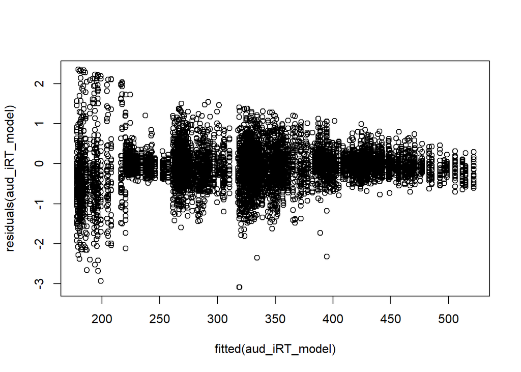

```r
# residual plots for visual inspection
plot(fitted(aud_iRT_model),residuals(aud_iRT_model))
```

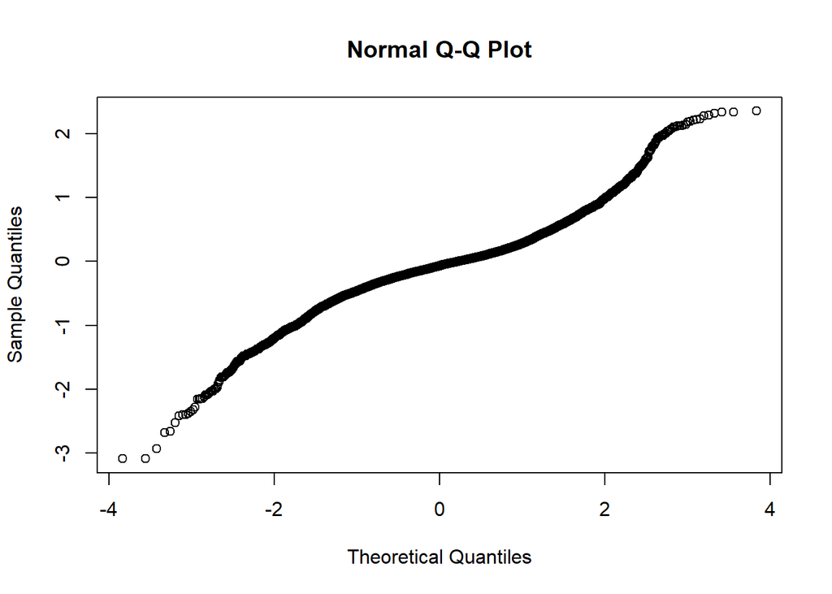

```r
qqnorm(residuals(aud_iRT_model))
```

```r
# get R square
rsq.glmm(aud_iRT_model)
```

```
## $model
## [1] 0.1307752
##
## $fixed
## [1] 0.009840257
##
## $random
## [1] 0.1209349
```

```r
# ====================================================================
# Onset:
onset_event_table2 = all_event_table2 %>% filter(SOA_lock == "onset")
aud_iRT_model_onset = glmer(iRT_aud ~ f_SOA*c_task_relevant +
                     (1*f_SOA*c_task_relevant | sub_id),
                   family=Gamma(link="log"), data=onset_event_table2)
summary(aud_iRT_model_onset)
```

```
## Generalized linear mixed model fit by maximum likelihood (Laplace
##   Approximation) [glmerMod]
##  Family: Gamma  ( log )
## Formula: iRT_aud ~ f_SOA * c_task_relevant + (1 * f_SOA * c_task_relevant |
##     sub_id)
##    Data: onset_event_table2
##
##      AIC      BIC   logLik deviance df.resid
##  51294.1  51344.4 -25639.0  51278.1     3991
##
## Scaled residuals:
##     Min      1Q  Median      3Q     Max
## -1.9512 -0.5237 -0.1256  0.2933  8.0765
##
## Random effects:
##  Groups   Name        Variance Std.Dev.
##  sub_id   (Intercept) 0.0196   0.1400
##  Residual             0.2612   0.5111
## Number of obs: 3999, groups:  sub_id, 10
##
## Fixed effects:
##                         Estimate Std. Error t value Pr(>|z|)
## (Intercept)              5.79869    0.08373  69.258  < 2e-16 ***
## f_SOA.L                 -0.07941    0.01332  -5.960 2.53e-09 ***
## f_SOA.Q                  0.04763    0.01320   3.607 0.000309 ***
## c_task_relevant          0.06498    0.01532   4.242 2.22e-05 ***
## f_SOA.L:c_task_relevant  0.02388    0.02660   0.898 0.369364
## f_SOA.Q:c_task_relevant  0.01130    0.02640   0.428 0.668513
## ---
## Signif. codes:  0 '***' 0.001 '**' 0.01 '*' 0.05 '.' 0.1 ' ' 1
##
## Correlation of Fixed Effects:
##             (Intr) f_SOA.L f_SOA.Q c_tsk_ f_SOA.L:
## f_SOA.L      0.000
## f_SOA.Q      0.001 -0.004
## c_tsk_rlvnt  0.000 -0.010  -0.001
## f_SOA.L:c__ -0.001 -0.001  -0.005  -0.003
## f_SOA.Q:c__  0.000 -0.006   0.003   0.012 -0.002
```

```r
# get chisquare and p values
anova_results <- Anova(aud_iRT_model_onset)
write.csv(anova_results, file = file.path(save_dir, "Experiment2-iT2_onset_mdl_anova.csv"), row.names = TRUE)
anova_results
```

```
## Analysis of Deviance Table (Type II Wald chisquare tests)
##
## Response: iRT_aud
##                        Chisq Df Pr(>Chisq)
## f_SOA                 48.331  2  3.200e-11 ***
## c_task_relevant       17.976  1  2.238e-05 ***
## f_SOA:c_task_relevant  0.991  2     0.6093
## ---
## Signif. codes:  0 '***' 0.001 '**' 0.01 '*' 0.05 '.' 0.1 ' ' 1
```

```r
# Compute pairwise comparison between SOA conditions for the onset locked trials:
em2 <- emmeans(aud_iRT_model_onset, "f_SOA")
```

```
## NOTE: Results may be misleading due to involvement in interactions
```

```r
onset_soa_contrats <- contrast(em2, "pairwise", adjust = "bonferroni")
# Save to file:
write.csv(onset_soa_contrats, file = file.path(save_dir, "Experiment2-iT2_onset_soa_contrasts.csv"), row.names = TRUE)

# ====================================================================
# Offset:
offset_event_table2 = all_event_table2 %>% filter(SOA_lock == "offset")
aud_iRT_model_offset = glmer(iRT_aud ~ f_SOA*c_task_relevant*f_duration +
                     (1*f_SOA*f_duration*c_task_relevant | sub_id),
                   family=Gamma(link="log"), data=offset_event_table2)
summary(aud_iRT_model_offset)
```

```
## Generalized linear mixed model fit by maximum likelihood (Laplace
##   Approximation) [glmerMod]
##  Family: Gamma  ( log )
## Formula: iRT_aud ~ f_SOA * c_task_relevant * f_duration + (1 * f_SOA *
##     f_duration * c_task_relevant | sub_id)
##    Data: offset_event_table2
##
##      AIC      BIC   logLik deviance df.resid
##  51089.5  51215.4 -25524.7  51049.5     3985
##
## Scaled residuals:
##     Min      1Q  Median      3Q     Max
## -1.8603 -0.5145 -0.1193  0.2708  8.7951
##
## Random effects:
##  Groups   Name        Variance Std.Dev.
##  sub_id   (Intercept) 0.02704  0.1644
##  Residual             0.28690  0.5356
## Number of obs: 4005, groups:  sub_id, 10
##
## Fixed effects:
##                                       Estimate Std. Error t value Pr(>|z|)
## (Intercept)                           5.741055   0.094640  60.662   <2e-16 ***
## f_SOA.L                              -0.025378   0.013564  -1.871   0.0614 .
## f_SOA.Q                               0.007878   0.013524   0.583   0.5602
## c_task_relevant                       0.034005   0.015629   2.176   0.0296 *
## f_duration.L                         -0.014434   0.013510  -1.068   0.2854
## f_duration.Q                         -0.025773   0.013560  -1.901   0.0573 .
## f_SOA.L:c_task_relevant              -0.057248   0.027087  -2.113   0.0346 *
## f_SOA.Q:c_task_relevant              -0.014053   0.027042  -0.520   0.6033
## f_SOA.L:f_duration.L                 -0.033371   0.023386  -1.427   0.1536
## f_SOA.Q:f_duration.L                  0.004587   0.023409   0.196   0.8447
## f_SOA.L:f_duration.Q                 -0.005738   0.023536  -0.244   0.8074
## f_SOA.Q:f_duration.Q                  0.016872   0.023435   0.720   0.4716
## c_task_relevant:f_duration.L          0.009904   0.027011   0.367   0.7139
## c_task_relevant:f_duration.Q         -0.020290   0.027123  -0.748   0.4544
## f_SOA.L:c_task_relevant:f_duration.L -0.021141   0.046769  -0.452   0.6513
## f_SOA.Q:c_task_relevant:f_duration.L  0.033621   0.046808   0.718   0.4726
## f_SOA.L:c_task_relevant:f_duration.Q -0.042746   0.047096  -0.908   0.3641
## f_SOA.Q:c_task_relevant:f_duration.Q -0.020273   0.046882  -0.432   0.6654
## ---
## Signif. codes:  0 '***' 0.001 '**' 0.01 '*' 0.05 '.' 0.1 ' ' 1
```

```
##
## Correlation matrix not shown by default, as p = 18 > 12.
## Use print(x, correlation=TRUE)  or
##     vcov(x)        if you need it
```

```r
# get chisquare and p values
anova_results <- Anova(aud_iRT_model_offset)
write.csv(anova_results, file = file.path(save_dir, "Experiment2-iT2_offset_mdl_anova.csv"), row.names = TRUE)
anova_results
```

```
## Analysis of Deviance Table (Type II Wald chisquare tests)
##
## Response: iRT_aud
##                                   Chisq Df Pr(>Chisq)
## f_SOA                            3.8274  2    0.14754
## c_task_relevant                  4.7595  1    0.02914 *
## f_duration                       4.7780  2    0.09172 .
## f_SOA:c_task_relevant            4.7851  2    0.09140 .
## f_SOA:f_duration                 2.6300  4    0.62152
## c_task_relevant:f_duration       0.6784  2    0.71234
## f_SOA:c_task_relevant:f_duration 1.7311  4    0.78506
## ---
## Signif. codes:  0 '***' 0.001 '**' 0.01 '*' 0.05 '.' 0.1 ' ' 1
```

### iT1 analysis

Pre-registered “To analyze the effects of our experimental variables on ITaud and ITvis, a similar generalized linear model as for experiment 1 will be fitted: ITaudio/visual ~ SOA x onset/offset x Task relevance + (SOA x onset/offset x Task relevance | Subject) + (SOA x onset/offset x Task relevance | Duration)”

```r
vis_iRT_model = glmer(iRT_vis ~ f_SOA*c_is_onset*c_task_relevant +
                     (1*f_SOA*c_is_onset*c_task_relevant | sub_id)+
                     (1*f_SOA*c_is_onset*c_task_relevant | f_duration),
                   family=Gamma(link="log"), data=all_event_table2)
summary(vis_iRT_model)
```

```
## Generalized linear mixed model fit by maximum likelihood (Laplace
##   Approximation) [glmerMod]
##  Family: Gamma  ( log )
## Formula: iRT_vis ~ f_SOA * c_is_onset * c_task_relevant + (1 * f_SOA *
##     c_is_onset * c_task_relevant | sub_id) + (1 * f_SOA * c_is_onset *
##     c_task_relevant | f_duration)
##    Data: all_event_table2
##
##      AIC      BIC   logLik deviance df.resid
##  95975.9  96080.7 -47973.0  95945.9     7989
##
## Scaled residuals:
##     Min      1Q  Median      3Q     Max
## -1.7974 -0.5994 -0.1637  0.3628 11.2619
##
## Random effects:
##  Groups     Name        Variance  Std.Dev.
##  sub_id     (Intercept) 0.1183835 0.34407
##  f_duration (Intercept) 0.0003288 0.01813
##  Residual               0.3074270 0.55446
## Number of obs: 8004, groups:  sub_id, 10; f_duration, 3
##
## Fixed effects:
##                                     Estimate Std. Error t value Pr(>|z|)
## (Intercept)                         5.275408   0.196389  26.862  < 2e-16 ***
## f_SOA.L                            -0.031492   0.010671  -2.951 0.003166 **
## f_SOA.Q                             0.028137   0.010620   2.649 0.008064 **
## c_is_onset                          0.065772   0.012305   5.345 9.03e-08 ***
## c_task_relevant                     0.218612   0.012302  17.770  < 2e-16 ***
## f_SOA.L:c_is_onset                 -0.078753   0.021338  -3.691 0.000224 ***
## f_SOA.Q:c_is_onset                  0.039322   0.021239   1.851 0.064112 .
## f_SOA.L:c_task_relevant             0.005868   0.021340   0.275 0.783341
## f_SOA.Q:c_task_relevant            -0.009924   0.021237  -0.467 0.640284
## c_is_onset:c_task_relevant          0.042929   0.024590   1.746 0.080848 .
## f_SOA.L:c_is_onset:c_task_relevant -0.035020   0.042679  -0.821 0.411905
## f_SOA.Q:c_is_onset:c_task_relevant  0.007096   0.042474   0.167 0.867311
## ---
## Signif. codes:  0 '***' 0.001 '**' 0.01 '*' 0.05 '.' 0.1 ' ' 1
##
## Correlation of Fixed Effects:
```

[output cut: 9 more lines]

```
## c_s_nst:c__   0.000  0.001  -0.002   0.000 -0.001 -0.009        0.001
## f_SOA.L:__:   0.000 -0.001   0.001  -0.009 -0.005  0.000       -0.006
## f_SOA.Q:__:   0.000  0.001   0.002   0.000  0.004 -0.006        0.000
##              f_SOA.L:c_t_ f_SOA.Q:c_t_ c__:__ f_SOA.L:__:
## f_SOA.L
## f_SOA.Q
## c_is_onset
## c_tsk_rlvnt
## f_SOA.L:c_s_
## f_SOA.Q:c_s_
## f_SOA.L:c_t_
## f_SOA.Q:c_t_  0.001
## c_s_nst:c__  -0.005        0.005
## f_SOA.L:__:   0.003       -0.003        0.001
## f_SOA.Q:__:  -0.003       -0.003        0.007  0.001
```

```r
# get chisquare and p values
anova_results <- Anova(vis_iRT_model)
write.csv(anova_results, file = file.path(save_dir, "Experiment2-iT1_full_mdl_anova.csv"), row.names = TRUE)
anova_results
```

```
## Analysis of Deviance Table (Type II Wald chisquare tests)
##
## Response: iRT_vis
##                                     Chisq Df Pr(>Chisq)
## f_SOA                             15.6211  2  0.0004054 ***
## c_is_onset                        28.3880  1  9.928e-08 ***
## c_task_relevant                  315.7738  1  < 2.2e-16 ***
## f_SOA:c_is_onset                  17.0354  2  0.0001999 ***
## f_SOA:c_task_relevant              0.2979  2  0.8616333
## c_is_onset:c_task_relevant         3.0478  1  0.0808483 .
## f_SOA:c_is_onset:c_task_relevant   0.7015  2  0.7041634
## ---
## Signif. codes:  0 '***' 0.001 '**' 0.01 '*' 0.05 '.' 0.1 ' ' 1
```

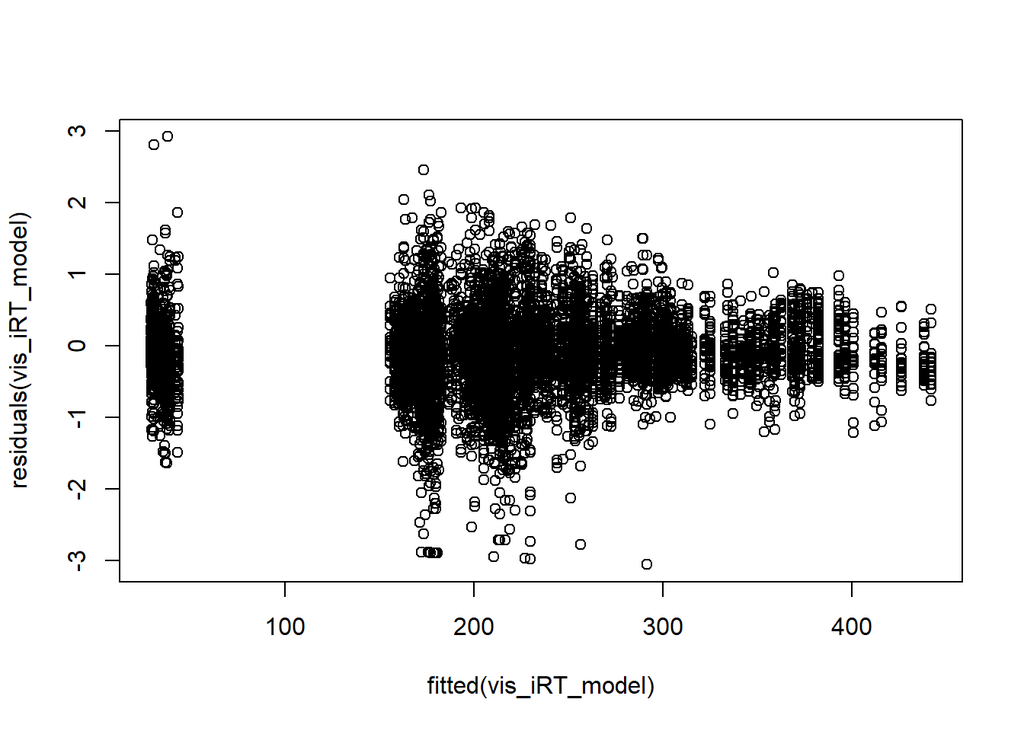

```r
# residual plots for visual inspection
plot(fitted(vis_iRT_model),residuals(vis_iRT_model))
```

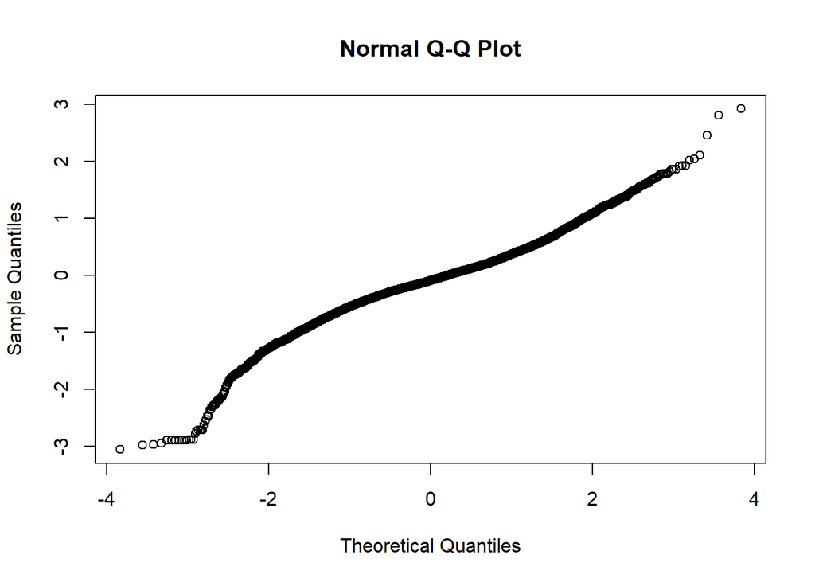

```r
qqnorm(residuals(vis_iRT_model))
```

```r
# get R square
rsq.glmm(vis_iRT_model)
```

```
## $model
## [1] 0.1918554
##
## $fixed
## [1] 0.03350653
##
## $random
## [1] 0.1583489
```

```r
# ====================================================================
# Onset:
onset_event_table2 = all_event_table2 %>% filter(SOA_lock == "onset")
vis_iRT_model_onset = glmer(iRT_vis ~ f_SOA*c_task_relevant +
                     (1*f_SOA*c_task_relevant | sub_id),
                   family=Gamma(link="log"), data=onset_event_table2)
summary(vis_iRT_model_onset)
```

```
## Generalized linear mixed model fit by maximum likelihood (Laplace
##   Approximation) [glmerMod]
##  Family: Gamma  ( log )
## Formula: iRT_vis ~ f_SOA * c_task_relevant + (1 * f_SOA * c_task_relevant |
##     sub_id)
##    Data: onset_event_table2
##
##      AIC      BIC   logLik deviance df.resid
##  48188.1  48238.4 -24086.0  48172.1     3991
##
## Scaled residuals:
##     Min      1Q  Median      3Q     Max
## -1.7583 -0.5853 -0.1805  0.3424 10.6167
##
## Random effects:
##  Groups   Name        Variance Std.Dev.
##  sub_id   (Intercept) 0.1220   0.3493
##  Residual             0.3209   0.5665
## Number of obs: 3999, groups:  sub_id, 10
##
## Fixed effects:
##                          Estimate Std. Error t value Pr(>|z|)
## (Intercept)              5.307929   0.194134  27.342  < 2e-16 ***
## f_SOA.L                 -0.068233   0.015060  -4.531 5.88e-06 ***
## f_SOA.Q                  0.046244   0.014942   3.095  0.00197 **
## c_task_relevant          0.238665   0.017327  13.774  < 2e-16 ***
## f_SOA.L:c_task_relevant -0.010121   0.030114  -0.336  0.73681
## f_SOA.Q:c_task_relevant -0.005486   0.029878  -0.184  0.85432
## ---
## Signif. codes:  0 '***' 0.001 '**' 0.01 '*' 0.05 '.' 0.1 ' ' 1
##
## Correlation of Fixed Effects:
##             (Intr) f_SOA.L f_SOA.Q c_tsk_ f_SOA.L:
## f_SOA.L      0.000
## f_SOA.Q      0.001 -0.003
## c_tsk_rlvnt  0.000 -0.008  -0.001
## f_SOA.L:c__  0.000 -0.001  -0.005  -0.003
## f_SOA.Q:c__  0.000 -0.005   0.002   0.011 -0.002
```

```r
# get chisquare and p values
anova_results <- Anova(vis_iRT_model_onset)
write.csv(anova_results, file = file.path(save_dir, "Experiment2-iT1_onset_mdl_anova.csv"), row.names = TRUE)
anova_results
```

```
## Analysis of Deviance Table (Type II Wald chisquare tests)
##
## Response: iRT_vis
##                         Chisq Df Pr(>Chisq)
## f_SOA                  30.019  2   3.03e-07 ***
## c_task_relevant       189.780  1  < 2.2e-16 ***
## f_SOA:c_task_relevant   0.147  2     0.9292
## ---
## Signif. codes:  0 '***' 0.001 '**' 0.01 '*' 0.05 '.' 0.1 ' ' 1
```

```r
# post hoc pairwise comparisons using bonferroni corrected t-testing
em2 <- emmeans(vis_iRT_model_onset, "f_SOA")
```

```
## NOTE: Results may be misleading due to involvement in interactions
```

```r
onset_soa_contrats <- contrast(em2, "pairwise", adjust = "bonferroni")
# Save to file:
write.csv(onset_soa_contrats, file = file.path(save_dir, "Experiment2-iT1_onset_soa_contrasts.csv"), row.names = TRUE)

# ====================================================================
# Offset:
offset_event_table2 = all_event_table2 %>% filter(SOA_lock == "offset")
vis_iRT_model_offset = glmer(iRT_vis ~ f_SOA*c_task_relevant*f_duration +
                     (1*f_SOA*f_duration*c_task_relevant | sub_id),
                   family=Gamma(link="log"), data=offset_event_table2)
summary(vis_iRT_model_offset)
```

```
## Generalized linear mixed model fit by maximum likelihood (Laplace
##   Approximation) [glmerMod]
##  Family: Gamma  ( log )
## Formula: iRT_vis ~ f_SOA * c_task_relevant * f_duration + (1 * f_SOA *
##     f_duration * c_task_relevant | sub_id)
##    Data: offset_event_table2
##
##      AIC      BIC   logLik deviance df.resid
##  47792.0  47917.9 -23876.0  47752.0     3985
##
## Scaled residuals:
##     Min      1Q  Median      3Q     Max
## -1.8509 -0.6097 -0.1452  0.3809  6.6320
##
## Random effects:
##  Groups   Name        Variance Std.Dev.
##  sub_id   (Intercept) 0.1167   0.3416
##  Residual             0.2900   0.5385
## Number of obs: 4005, groups:  sub_id, 10
##
## Fixed effects:
##                                        Estimate Std. Error t value Pr(>|z|)
## (Intercept)                           5.2400092  0.1997836  26.228   <2e-16 ***
## f_SOA.L                               0.0070184  0.0150012   0.468   0.6399
## f_SOA.Q                               0.0095365  0.0149788   0.637   0.5243
## c_task_relevant                       0.1970716  0.0173431  11.363   <2e-16 ***
## f_duration.L                          0.0282139  0.0149802   1.883   0.0596 .
## f_duration.Q                         -0.0288449  0.0150201  -1.920   0.0548 .
## f_SOA.L:c_task_relevant               0.0243266  0.0300113   0.811   0.4176
## f_SOA.Q:c_task_relevant              -0.0149016  0.0299520  -0.498   0.6188
## f_SOA.L:f_duration.L                 -0.0114973  0.0259045  -0.444   0.6572
## f_SOA.Q:f_duration.L                  0.0118686  0.0259182   0.458   0.6470
## f_SOA.L:f_duration.Q                 -0.0517925  0.0260642  -1.987   0.0469 *
## f_SOA.Q:f_duration.Q                 -0.0039256  0.0259630  -0.151   0.8798
## c_task_relevant:f_duration.L          0.0208473  0.0299176   0.697   0.4859
## c_task_relevant:f_duration.Q         -0.0006604  0.0300385  -0.022   0.9825
## f_SOA.L:c_task_relevant:f_duration.L  0.0213642  0.0518358   0.412   0.6802
## f_SOA.Q:c_task_relevant:f_duration.L  0.0133873  0.0518394   0.258   0.7962
## f_SOA.L:c_task_relevant:f_duration.Q -0.0714204  0.0521504  -1.370   0.1708
## f_SOA.Q:c_task_relevant:f_duration.Q -0.0436462  0.0519177  -0.841   0.4005
## ---
## Signif. codes:  0 '***' 0.001 '**' 0.01 '*' 0.05 '.' 0.1 ' ' 1
```

```
##
## Correlation matrix not shown by default, as p = 18 > 12.
## Use print(x, correlation=TRUE)  or
##     vcov(x)        if you need it
```

```r
# get chisquare and p values
anova_results <- Anova(vis_iRT_model_offset)
write.csv(anova_results, file = file.path(save_dir, "Experiment2-iT1_offset_mdl_anova.csv"), row.names = TRUE)
anova_results
```

```
## Analysis of Deviance Table (Type II Wald chisquare tests)
##
## Response: iRT_vis
##                                     Chisq Df Pr(>Chisq)
## f_SOA                              0.6189  2    0.73383
## c_task_relevant                  128.7336  1    < 2e-16 ***
## f_duration                         7.2504  2    0.02664 *
## f_SOA:c_task_relevant              0.8896  2    0.64095
## f_SOA:f_duration                   4.4250  4    0.35154
## c_task_relevant:f_duration         0.4945  2    0.78093
## f_SOA:c_task_relevant:f_duration   2.8087  4    0.59034
## ---
## Signif. codes:  0 '***' 0.001 '**' 0.01 '*' 0.05 '.' 0.1 ' ' 1
```

### Correlation between RT1-iT1 and RT2-iT2

correlation plots RT1 ~ iT1 and RT2 ~ iT2 - as preregistred

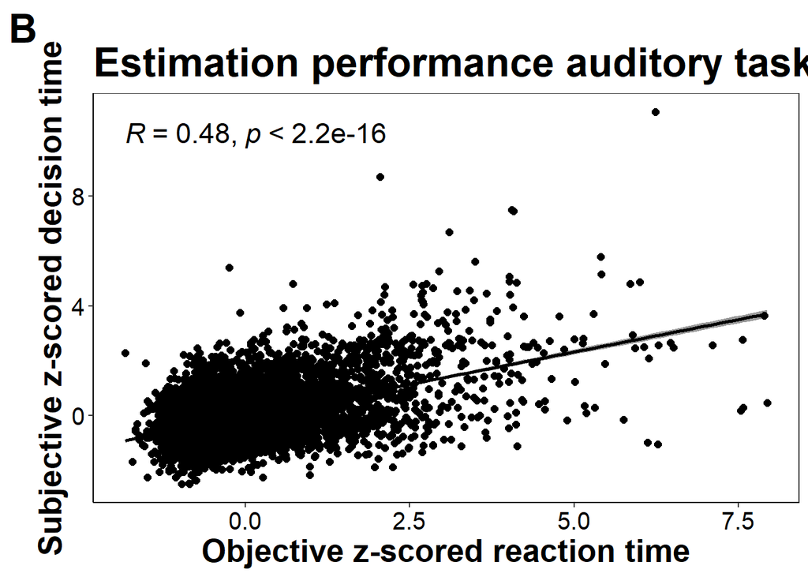

```r
# Further remove the trials in which participants failed to detect a target (which were not removed by previous bad trials rejection as the
# targets were excluded)
target_event_table2 = target_event_table2 %>% filter(trial_response_vis == "hit" | trial_response_vis == "cr")
# correlation for auditory RT (fig 8a)
corr_fig1 = ggscatter(target_event_table2 , x = "z_RT_aud", y = "z_iRT_aud",
          add = "reg.line", conf.int = TRUE,
          cor.coef = TRUE, cor.method = "pearson", cor.coef.size = 6)+
  labs(title = "Estimation performance auditory task", tag = "B")+
  xlab("Objective z-scored reaction time")+
  ylab('Subjective z-scored decision time')+
  theme_bw() +
  theme(axis.line = element_line(colour = "black"),
        panel.grid.major = element_blank(),
        panel.grid.minor = element_blank(),
        panel.border = element_rect(linetype = "solid"),
        panel.background = element_blank(),
        axis.text = element_text(color = "black", size = 15),
        legend.text = element_text(size = 20),
        legend.title = element_text(size = 20, face="bold"),
        axis.title = element_text(size = 20, face="bold"),
        plot.title = element_text(size = 25, face="bold"),
        plot.tag = element_text(size = 25, face="bold"))

# plot figure
print(corr_fig1)
```

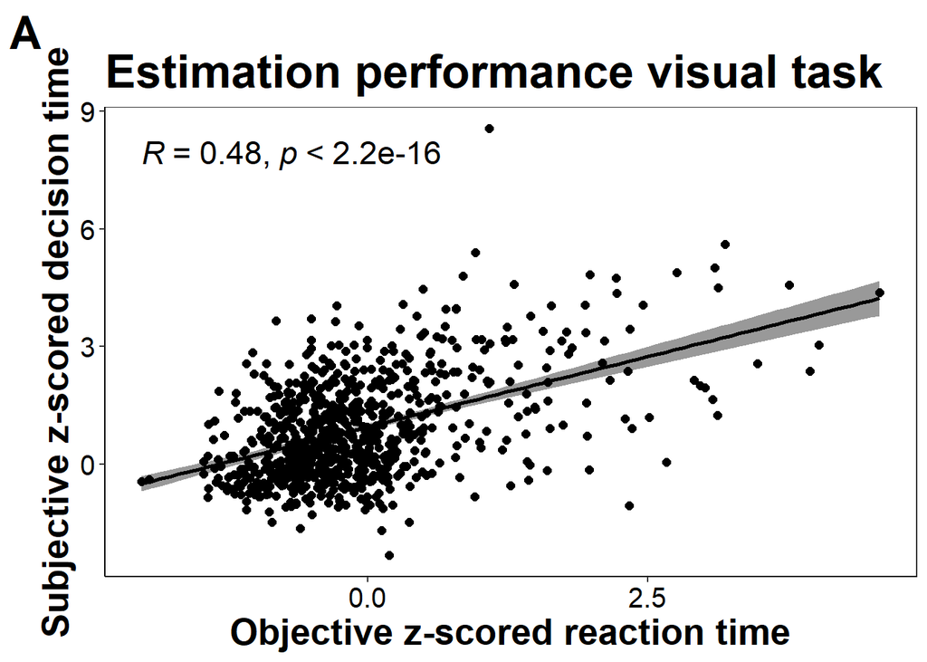

```r
# correlation for auditory RT (fig 8b)
target_only_event_table2 = target_event_table2 %>% filter(task_relevance == "target")
corr_fig2 = ggscatter(target_only_event_table2 , x = "z_RT_vis", y = "z_iRT_vis",
          add = "reg.line", conf.int = TRUE,
          cor.coef = TRUE,  cor.method = "pearson", cor.coef.size = 6)+
  labs(title = "Estimation performance visual task", tag = "A")+
  xlab("Objective z-scored reaction time")+
  ylab('Subjective z-scored decision time')+
  theme_bw() +
  theme(axis.line = element_line(colour = "black"),
        panel.grid.major = element_blank(),
        panel.grid.minor = element_blank(),
        panel.border = element_rect(linetype = "solid"),
        panel.background = element_blank(),
        axis.text = element_text(color = "black", size = 15),
        legend.text = element_text(size = 20),
        legend.title = element_text(size = 20, face="bold"),
        axis.title = element_text(size = 20, face="bold"),
        plot.title = element_text(size = 25, face="bold"),
        plot.tag = element_text(size = 25, face="bold"))

# plot figure
print(corr_fig2)
```

### Under-estimation of RT2 with iT2:

```r
# Centered RT2:
all_event_table2$iRT_aud_center = (all_event_table2$iRT_aud - mean(all_event_table2$iRT_aud)) / 1000

# Modelling RT_aud as a function of iT_aud to test for the under-estimation of RT
iRT_RT2_mdl = glmer(RT_aud  ~ iRT_aud_center +
                     (1 | sub_id),
                   family=Gamma(link="log"), data=all_event_table2)
summary(iRT_RT2_mdl)
```

```
## Generalized linear mixed model fit by maximum likelihood (Laplace
##   Approximation) [glmerMod]
##  Family: Gamma  ( log )
## Formula: RT_aud ~ iRT_aud_center + (1 | sub_id)
##    Data: all_event_table2
##
##      AIC      BIC   logLik deviance df.resid
##  -6532.4  -6504.5   3270.2  -6540.4     8000
##
## Scaled residuals:
##     Min      1Q  Median      3Q     Max
## -2.2031 -0.6253 -0.1707  0.3928 11.3412
##
## Random effects:
##  Groups   Name        Variance Std.Dev.
##  sub_id   (Intercept) 0.002883 0.05369
##  Residual             0.092244 0.30372
## Number of obs: 8004, groups:  sub_id, 10
##
## Fixed effects:
##                Estimate Std. Error t value Pr(>|z|)
## (Intercept)    -0.51500    0.04712  -10.93   <2e-16 ***
## iRT_aud_center  1.09907    0.02062   53.31   <2e-16 ***
## ---
## Signif. codes:  0 '***' 0.001 '**' 0.01 '*' 0.05 '.' 0.1 ' ' 1
##
## Correlation of Fixed Effects:
##             (Intr)
## iRT_ad_cntr 0.000
```

```r
# Convert the intercept back into sec by exponentiating:
intercept_original_scale <- exp(fixef(iRT_RT2_mdl)["(Intercept)"])
cat("Intercept on the original scale:", intercept_original_scale, "\n")
```

```
## Intercept on the original scale: 0.5975027
```

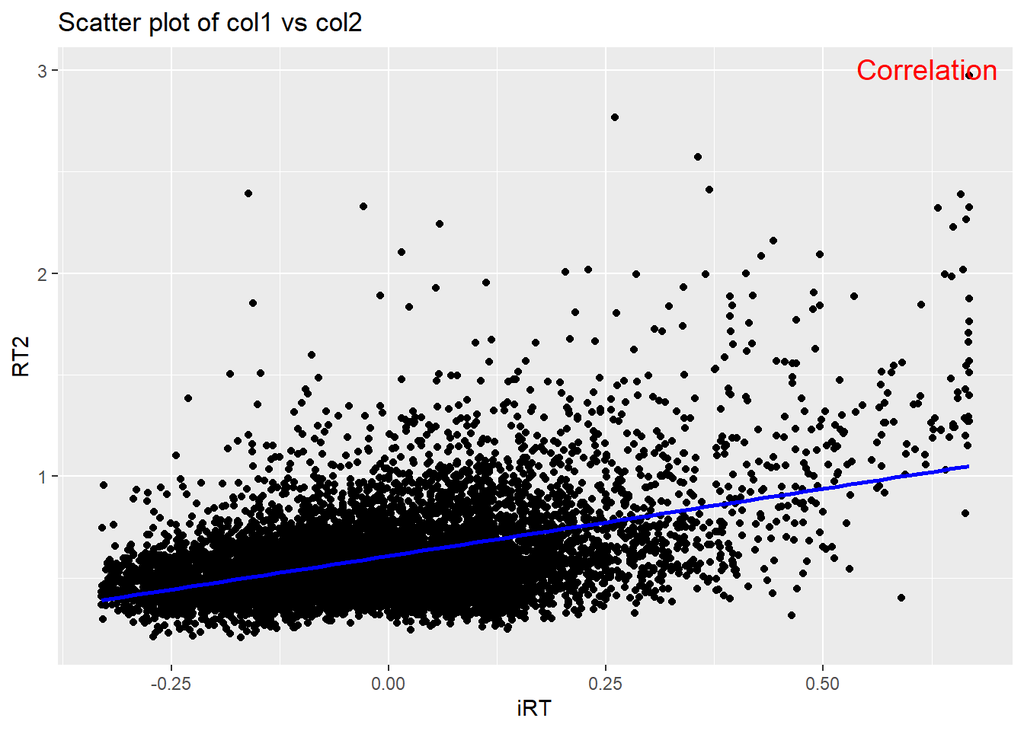

```r
plot <- ggplot(all_event_table2, aes(x = iRT_aud_center, y =RT_aud )) +
  geom_point() +
  geom_smooth(method = "lm", se = FALSE, color = "blue") +
  ggtitle(paste("Scatter plot of col1 vs col2")) +
  xlab("iRT") +
  ylab("RT2") +
  annotate("text", x = Inf, y = Inf, label = "Correlation",
           hjust = 1.1, vjust = 1.5, size = 5, color = "red")
print(plot)
```

### Relationship between T1 (iRTvis) and T2 (RTaud)

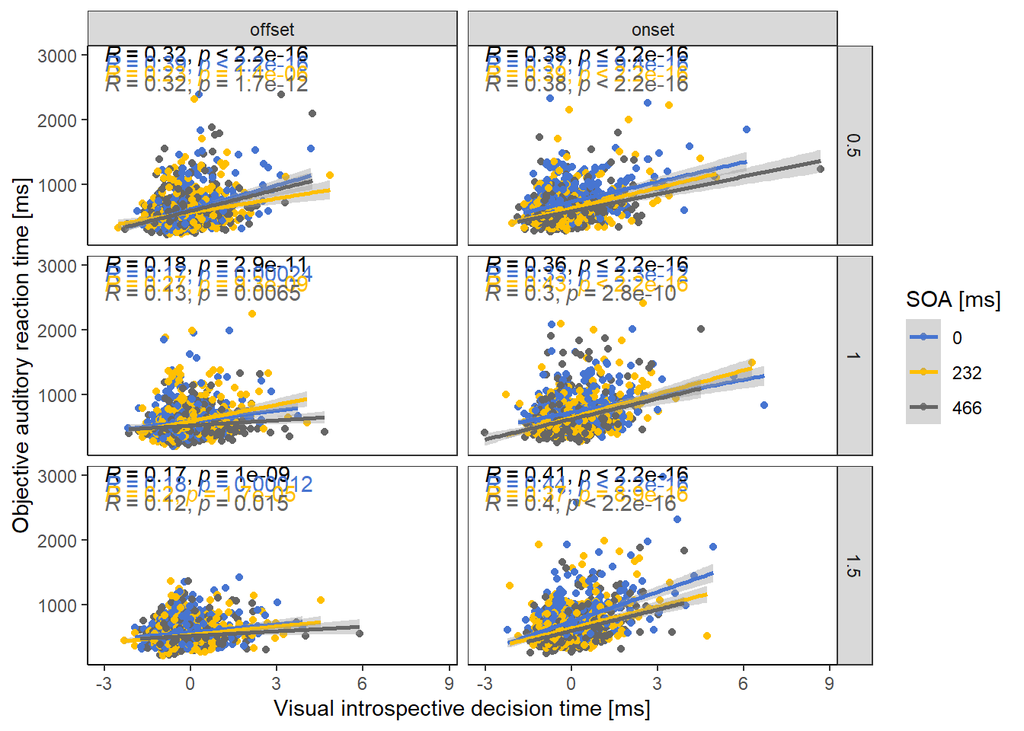

```r
# correlation analysis (showing correlation for different condition)
correlation_plot = ggplot(all_event_table2, aes(x = z_iRT_vis, y = RT_aud*1000, color = f_SOA)) +
  geom_point() +
  geom_smooth(method = "lm", se = TRUE, aes(group = f_SOA)) +
  xlab("Visual introspective decision time [ms]") +
  ylab("Objective auditory reaction time [ms]") +
  scale_color_manual(values = c("#4775d1", '#ffbf00', "#666666"), name = "SOA [ms]", labels = c("0", "232", "466")) +
  facet_grid(duration ~ SOA_lock)+
  theme_bw() +
  theme(axis.line = element_line(colour = "black"),
        panel.grid.major = element_blank(),
        panel.grid.minor = element_blank(),
        panel.border = element_rect(linetype = "solid"),
        panel.background = element_blank())+
  stat_cor(color = 'black', label.y = 3000, method = "pearson", show.legend = FALSE)+
  stat_cor(aes(color = f_SOA),label.y = c(2850,2700,2550), method = "pearson", show.legend = FALSE)
correlation_plot
```

```r
# ==============================================================================
# GLMM with iRTVis as predictor for RTaud
all_event_table2 = all_event_table2 %>% mutate(iRT_vis_0.001 = iRT_vis*0.001)
model_T1 = glmer(RT_aud ~ f_SOA*c_is_onset*c_task_relevant*iRT_vis_0.001 +
                   (1*f_SOA*c_is_onset*c_task_relevant*iRT_vis_0.001| sub_id)+
                   (1*f_SOA*c_is_onset*c_task_relevant*iRT_vis_0.001 | f_duration),
                 family=Gamma(link="identity"), data=all_event_table2)
summary(model_T1)
```

```
## Generalized linear mixed model fit by maximum likelihood (Laplace
##   Approximation) [glmerMod]
##  Family: Gamma  ( identity )
## Formula: RT_aud ~ f_SOA * c_is_onset * c_task_relevant * iRT_vis_0.001 +
##     (1 * f_SOA * c_is_onset * c_task_relevant * iRT_vis_0.001 |
##         sub_id) + (1 * f_SOA * c_is_onset * c_task_relevant *
##     iRT_vis_0.001 | f_duration)
##    Data: all_event_table2
##
##      AIC      BIC   logLik deviance df.resid
##  -5720.9  -5532.2   2887.5  -5774.9     7977
##
## Scaled residuals:
##     Min      1Q  Median      3Q     Max
## -1.7248 -0.6013 -0.2052  0.3144 10.0903
##
## Random effects:
##  Groups     Name        Variance  Std.Dev.
##  sub_id     (Intercept) 1.316e-03 0.036283
##  f_duration (Intercept) 3.927e-05 0.006266
##  Residual               1.095e-01 0.330873
## Number of obs: 8004, groups:  sub_id, 10; f_duration, 3
##
## Fixed effects:
##                                                   Estimate Std. Error t value
## (Intercept)                                       0.500737   0.032004  15.646
## f_SOA.L                                          -0.059230   0.006194  -9.562
## f_SOA.Q                                           0.022084   0.005930   3.724
## c_is_onset                                        0.059032   0.007020   8.409
## c_task_relevant                                   0.006080   0.007021   0.866
## iRT_vis_0.001                                     0.513870   0.018128  28.348
## f_SOA.L:c_is_onset                               -0.069911   0.012378  -5.648
## f_SOA.Q:c_is_onset                                0.029816   0.011854   2.515
## f_SOA.L:c_task_relevant                          -0.015628   0.012380  -1.262
## f_SOA.Q:c_task_relevant                           0.006446   0.011855   0.544
## c_is_onset:c_task_relevant                        0.009083   0.014008   0.648
## f_SOA.L:iRT_vis_0.001                            -0.025697   0.025182  -1.020
## f_SOA.Q:iRT_vis_0.001                            -0.036823   0.024854  -1.482
## c_is_onset:iRT_vis_0.001                          0.094299   0.029045   3.247
## c_task_relevant:iRT_vis_0.001                    -0.005136   0.029112  -0.176
```

[output cut: 21 more lines]

```
## f_SOA.L:iRT_vis_0.001                            0.307524
## f_SOA.Q:iRT_vis_0.001                            0.138450
## c_is_onset:iRT_vis_0.001                         0.001168 **
## c_task_relevant:iRT_vis_0.001                    0.859974
## f_SOA.L:c_is_onset:c_task_relevant               0.340489
## f_SOA.Q:c_is_onset:c_task_relevant               0.159644
## f_SOA.L:c_is_onset:iRT_vis_0.001                 0.631939
## f_SOA.Q:c_is_onset:iRT_vis_0.001                 0.690315
## f_SOA.L:c_task_relevant:iRT_vis_0.001            0.139291
## f_SOA.Q:c_task_relevant:iRT_vis_0.001            0.601997
## c_is_onset:c_task_relevant:iRT_vis_0.001         0.562052
## f_SOA.L:c_is_onset:c_task_relevant:iRT_vis_0.001 0.065073 .
## f_SOA.Q:c_is_onset:c_task_relevant:iRT_vis_0.001 0.091652 .
## ---
## Signif. codes:  0 '***' 0.001 '**' 0.01 '*' 0.05 '.' 0.1 ' ' 1
```

```
##
## Correlation matrix not shown by default, as p = 24 > 12.
## Use print(x, correlation=TRUE)  or
##     vcov(x)        if you need it
```

```
## optimizer (Nelder_Mead) convergence code: 0 (OK)
## Model failed to converge with max|grad| = 0.00483516 (tol = 0.002, component 1)
```

```r
anova_results <- Anova(model_T1)
write.csv(anova_results, file = file.path(save_dir, "Experiment2-iT1-RT2_anova.csv"), row.names = TRUE)
anova_results
```

```
## Analysis of Deviance Table (Type II Wald chisquare tests)
##
## Response: RT_aud
##                                                   Chisq Df Pr(>Chisq)
## f_SOA                                          306.7584  2  < 2.2e-16 ***
## c_is_onset                                     362.5122  1  < 2.2e-16 ***
## c_task_relevant                                  1.0234  1  0.3117180
## iRT_vis_0.001                                  835.5744  1  < 2.2e-16 ***
## f_SOA:c_is_onset                                99.4732  2  < 2.2e-16 ***
## f_SOA:c_task_relevant                            3.1883  2  0.2030777
## c_is_onset:c_task_relevant                       4.9878  1  0.0255272 *
## f_SOA:iRT_vis_0.001                              3.0093  2  0.2220917
## c_is_onset:iRT_vis_0.001                        11.9993  1  0.0005322 ***
## c_task_relevant:iRT_vis_0.001                    0.0062  1  0.9371866
## f_SOA:c_is_onset:c_task_relevant                 1.0836  2  0.5816889
## f_SOA:c_is_onset:iRT_vis_0.001                   0.6394  2  0.7263842
## f_SOA:c_task_relevant:iRT_vis_0.001              2.0819  2  0.3531198
## c_is_onset:c_task_relevant:iRT_vis_0.001         0.5379  1  0.4633039
## f_SOA:c_is_onset:c_task_relevant:iRT_vis_0.001   6.6988  2  0.0351057 *
## ---
## Signif. codes:  0 '***' 0.001 '**' 0.01 '*' 0.05 '.' 0.1 ' ' 1
```

```r
# ========================================================
# Onset trials:
onset_event_table2 = all_event_table2 %>% filter(SOA_lock == "onset")
model_T1_onset = glmer(RT_aud ~ f_SOA*c_task_relevant*iRT_vis_0.001 +
                   (1*f_SOA*c_task_relevant*iRT_vis_0.001| sub_id),
                 family=Gamma(link="identity"), data=onset_event_table2)
summary(model_T1_onset)
```

```
## Generalized linear mixed model fit by maximum likelihood (Laplace
##   Approximation) [glmerMod]
##  Family: Gamma  ( identity )
## Formula: RT_aud ~ f_SOA * c_task_relevant * iRT_vis_0.001 + (1 * f_SOA *
##     c_task_relevant * iRT_vis_0.001 | sub_id)
##    Data: onset_event_table2
##
##      AIC      BIC   logLik deviance df.resid
##  -2550.2  -2462.1   1289.1  -2578.2     3985
##
## Scaled residuals:
##     Min      1Q  Median      3Q     Max
## -1.8708 -0.6009 -0.2107  0.3424  8.9814
##
## Random effects:
##  Groups   Name        Variance Std.Dev.
##  sub_id   (Intercept) 0.001911 0.04371
##  Residual             0.100350 0.31678
## Number of obs: 3999, groups:  sub_id, 10
##
## Fixed effects:
##                                        Estimate Std. Error t value Pr(>|z|)
## (Intercept)                            0.524495   0.035836  14.636  < 2e-16 ***
## f_SOA.L                               -0.092664   0.009123 -10.157  < 2e-16 ***
## f_SOA.Q                                0.037525   0.008533   4.398 1.09e-05 ***
## c_task_relevant                        0.012597   0.010233   1.231   0.2183
## iRT_vis_0.001                          0.607530   0.024968  24.332  < 2e-16 ***
## f_SOA.L:c_task_relevant               -0.029931   0.018235  -1.641   0.1007
## f_SOA.Q:c_task_relevant               -0.011871   0.017057  -0.696   0.4864
## f_SOA.L:iRT_vis_0.001                 -0.010512   0.036287  -0.290   0.7721
## f_SOA.Q:iRT_vis_0.001                 -0.050786   0.035354  -1.437   0.1509
## c_task_relevant:iRT_vis_0.001         -0.008329   0.041576  -0.200   0.8412
## f_SOA.L:c_task_relevant:iRT_vis_0.001  0.174830   0.072389   2.415   0.0157 *
## f_SOA.Q:c_task_relevant:iRT_vis_0.001  0.116280   0.070610   1.647   0.0996 .
## ---
## Signif. codes:  0 '***' 0.001 '**' 0.01 '*' 0.05 '.' 0.1 ' ' 1
##
## Correlation of Fixed Effects:
##             (Intr) f_SOA.L f_SOA.Q c_tsk_ iRT__0 f_SOA.L:c__ f_SOA.Q:c__
## f_SOA.L     -0.026
## f_SOA.Q      0.012 -0.140
## c_tsk_rlvnt  0.004 -0.025   0.004
## iRT_v_0.001 -0.142  0.098  -0.036   0.064
## f_SOA.L:c__  0.000  0.020  -0.017  -0.188 -0.019
## f_SOA.Q:c__  0.000 -0.016   0.020   0.096 -0.004 -0.138
## f_SOA.L:RT_  0.014 -0.834   0.094   0.003 -0.068  0.066      -0.002
## f_SOA.Q:RT_ -0.005  0.090  -0.830  -0.004  0.008 -0.001       0.076
## c__:RT__0.0  0.016  0.002  -0.005  -0.830 -0.196  0.124      -0.057
## f_SOA.L:__: -0.003  0.068  -0.002   0.123  0.036 -0.835       0.091
## f_SOA.Q:__:  0.000 -0.002   0.076  -0.057  0.012  0.088      -0.830
##             f_SOA.L:R f_SOA.Q:R c__:RT f_SOA.L:__:
## f_SOA.L
## f_SOA.Q
## c_tsk_rlvnt
## iRT_v_0.001
## f_SOA.L:c__
## f_SOA.Q:c__
## f_SOA.L:RT_
## f_SOA.Q:RT_ -0.085
## c__:RT__0.0  0.017     0.018
## f_SOA.L:__: -0.161     0.019    -0.114
## f_SOA.Q:__:  0.019    -0.188     0.033 -0.082
```

```r
anova_results <- Anova(model_T1_onset)
write.csv(anova_results, file = file.path(save_dir, "Experiment2-iT1-RT2_onset_anova.csv"), row.names = TRUE)
anova_results
```

```
## Analysis of Deviance Table (Type II Wald chisquare tests)
##
## Response: RT_aud
##                                        Chisq Df Pr(>Chisq)
## f_SOA                               363.4836  2  < 2.2e-16 ***
## c_task_relevant                       3.9406  1   0.047135 *
## iRT_vis_0.001                       614.0105  1  < 2.2e-16 ***
## f_SOA:c_task_relevant                 1.8183  2   0.402865
## f_SOA:iRT_vis_0.001                   1.3386  2   0.512077
## c_task_relevant:iRT_vis_0.001         0.0010  1   0.974793
## f_SOA:c_task_relevant:iRT_vis_0.001   9.2570  2   0.009769 **
## ---
## Signif. codes:  0 '***' 0.001 '**' 0.01 '*' 0.05 '.' 0.1 ' ' 1
```

```r
# ========================================================
# Offset trials:
offset_event_table2 = all_event_table2 %>% filter(SOA_lock == "offset")
model_T1_offset = glmer(RT_aud ~ f_SOA*f_duration*iRT_vis_0.001 +
                   (1*f_SOA*f_duration*iRT_vis_0.001| sub_id),
                 family=Gamma(link="identity"), data=offset_event_table2)
summary(model_T1_offset)
```

```
## Generalized linear mixed model fit by maximum likelihood (Laplace
##   Approximation) [glmerMod]
##  Family: Gamma  ( identity )
## Formula:
## RT_aud ~ f_SOA * f_duration * iRT_vis_0.001 + (1 * f_SOA * f_duration *
##     iRT_vis_0.001 | sub_id)
##    Data: offset_event_table2
##
##      AIC      BIC   logLik deviance df.resid
##  -3306.9  -3180.9   1673.4  -3346.9     3985
##
## Scaled residuals:
##     Min      1Q  Median      3Q     Max
## -1.7584 -0.5980 -0.1944  0.3113 10.5118
##
## Random effects:
##  Groups   Name        Variance Std.Dev.
##  sub_id   (Intercept) 0.001392 0.0373
##  Residual             0.113832 0.3374
## Number of obs: 4005, groups:  sub_id, 10
##
## Fixed effects:
##                                     Estimate Std. Error t value Pr(>|z|)
## (Intercept)                         0.483176   0.028696  16.838  < 2e-16 ***
## f_SOA.L                            -0.025270   0.008032  -3.146  0.00165 **
## f_SOA.Q                             0.005192   0.007923   0.655  0.51221
## f_duration.L                        0.008722   0.007938   1.099  0.27186
## f_duration.Q                       -0.006688   0.008039  -0.832  0.40543
## iRT_vis_0.001                       0.404715   0.024701  16.384  < 2e-16 ***
## f_SOA.L:f_duration.L               -0.031985   0.013734  -2.329  0.01987 *
## f_SOA.Q:f_duration.L                0.010950   0.013683   0.800  0.42356
## f_SOA.L:f_duration.Q                0.004940   0.014073   0.351  0.72554
## f_SOA.Q:f_duration.Q               -0.008717   0.013758  -0.634  0.52636
## f_SOA.L:iRT_vis_0.001              -0.036133   0.033257  -1.087  0.27726
## f_SOA.Q:iRT_vis_0.001              -0.017419   0.033079  -0.527  0.59847
## f_duration.L:iRT_vis_0.001         -0.141878   0.033601  -4.222 2.42e-05 ***
## f_duration.Q:iRT_vis_0.001          0.024415   0.032852   0.743  0.45737
## f_SOA.L:f_duration.L:iRT_vis_0.001  0.086576   0.058093   1.490  0.13615
## f_SOA.Q:f_duration.L:iRT_vis_0.001 -0.066566   0.057825  -1.151  0.24966
## f_SOA.L:f_duration.Q:iRT_vis_0.001  0.059028   0.057055   1.035  0.30087
## f_SOA.Q:f_duration.Q:iRT_vis_0.001  0.164876   0.056730   2.906  0.00366 **
## ---
## Signif. codes:  0 '***' 0.001 '**' 0.01 '*' 0.05 '.' 0.1 ' ' 1
```

```
##
## Correlation matrix not shown by default, as p = 18 > 12.
## Use print(x, correlation=TRUE)  or
##     vcov(x)        if you need it
```

```
## optimizer (Nelder_Mead) convergence code: 0 (OK)
## Model failed to converge with max|grad| = 0.0028392 (tol = 0.002, component 1)
```

```r
anova_results <- Anova(model_T1_offset)
write.csv(anova_results, file = file.path(save_dir, "Experiment2-iT1-RT2_offset_anova.csv"), row.names = TRUE)
anova_results
```

```
## Analysis of Deviance Table (Type II Wald chisquare tests)
##
## Response: RT_aud
##                                   Chisq Df Pr(>Chisq)
## f_SOA                           56.8142  2  4.602e-13 ***
## f_duration                      19.5483  2  5.690e-05 ***
## iRT_vis_0.001                  259.3127  1  < 2.2e-16 ***
## f_SOA:f_duration                20.1142  4  0.0004741 ***
## f_SOA:iRT_vis_0.001              1.9054  2  0.3856993
## f_duration:iRT_vis_0.001        18.2805  2  0.0001073 ***
## f_SOA:f_duration:iRT_vis_0.001  13.1333  4  0.0106426 *
## ---
## Signif. codes:  0 '***' 0.001 '**' 0.01 '*' 0.05 '.' 0.1 ' ' 1
```

```r
# ==============================
# Short trials
offset_short_event_table2 = offset_event_table2 %>% filter(duration == 0.5)
model_T1_offset_short = glmer(RT_aud ~ f_SOA*iRT_vis_0.001 +
                   (1*f_SOA*iRT_vis_0.001| sub_id),
                 family=Gamma(link="identity"), data=offset_short_event_table2)
summary(model_T1_offset_short)
```

```
## Generalized linear mixed model fit by maximum likelihood (Laplace
##   Approximation) [glmerMod]
##  Family: Gamma  ( identity )
## Formula: RT_aud ~ f_SOA * iRT_vis_0.001 + (1 * f_SOA * iRT_vis_0.001 |
##     sub_id)
##    Data: offset_short_event_table2
##
##      AIC      BIC   logLik deviance df.resid
##   -839.4   -797.8    427.7   -855.4     1333
##
## Scaled residuals:
##     Min      1Q  Median      3Q     Max
## -1.4961 -0.5820 -0.2021  0.2535  8.5671
##
## Random effects:
##  Groups   Name        Variance Std.Dev.
##  sub_id   (Intercept) 0.002705 0.05201
##  Residual             0.139014 0.37285
## Number of obs: 1341, groups:  sub_id, 10
##
## Fixed effects:
##                         Estimate Std. Error t value Pr(>|z|)
## (Intercept)            0.4637202  0.0346825  13.370   <2e-16 ***
## f_SOA.L               -0.0004342  0.0150761  -0.029    0.977
## f_SOA.Q               -0.0051212  0.0155963  -0.328    0.743
## iRT_vis_0.001          0.5826388  0.0506449  11.504   <2e-16 ***
## f_SOA.L:iRT_vis_0.001 -0.0667050  0.0664732  -1.003    0.316
## f_SOA.Q:iRT_vis_0.001  0.0874589  0.0680441   1.285    0.199
## ---
## Signif. codes:  0 '***' 0.001 '**' 0.01 '*' 0.05 '.' 0.1 ' ' 1
##
## Correlation of Fixed Effects:
##             (Intr) f_SOA.L f_SOA.Q iRT__0 f_SOA.L:
## f_SOA.L     -0.009
## f_SOA.Q     -0.018 -0.010
## iRT_v_0.001 -0.278  0.027   0.054
## f_SOA.L:RT_  0.006 -0.831   0.011  -0.029
## f_SOA.Q:RT_  0.019  0.011  -0.850  -0.053 -0.021
```

```r
anova_results <- Anova(model_T1_offset_short)
write.csv(anova_results, file = file.path(save_dir, "Experiment2-iT1-RT2_offset_short_anova.csv"), row.names = TRUE)
anova_results
```

```
## Analysis of Deviance Table (Type II Wald chisquare tests)
##
## Response: RT_aud
##                        Chisq Df Pr(>Chisq)
## f_SOA                 4.3107  2     0.1159
## iRT_vis_0.001       133.7430  1     <2e-16 ***
## f_SOA:iRT_vis_0.001   2.6049  2     0.2719
## ---
## Signif. codes:  0 '***' 0.001 '**' 0.01 '*' 0.05 '.' 0.1 ' ' 1
```

```r
# ==============================
# Intermediate trials
offset_int_event_table2 = offset_event_table2 %>% filter(duration == 1.0)
model_T1_offset_int = glmer(RT_aud ~ f_SOA*iRT_vis_0.001 +
                   (1*f_SOA*iRT_vis_0.001| sub_id),
                 family=Gamma(link="identity"), data=offset_int_event_table2)
summary(model_T1_offset_int)
```

```
## Generalized linear mixed model fit by maximum likelihood (Laplace
##   Approximation) [glmerMod]
##  Family: Gamma  ( identity )
## Formula: RT_aud ~ f_SOA * iRT_vis_0.001 + (1 * f_SOA * iRT_vis_0.001 |
##     sub_id)
##    Data: offset_int_event_table2
##
##      AIC      BIC   logLik deviance df.resid
##  -1086.2  -1044.7    551.1  -1102.2     1317
##
## Scaled residuals:
##     Min      1Q  Median      3Q     Max
## -1.8105 -0.6023 -0.1850  0.3068  7.9820
##
## Random effects:
##  Groups   Name        Variance Std.Dev.
##  sub_id   (Intercept) 0.002244 0.04737
##  Residual             0.111864 0.33446
## Number of obs: 1325, groups:  sub_id, 10
##
## Fixed effects:
##                       Estimate Std. Error t value Pr(>|z|)
## (Intercept)            0.49073    0.03357  14.618  < 2e-16 ***
## f_SOA.L               -0.02755    0.01407  -1.958  0.05022 .
## f_SOA.Q                0.01266    0.01362   0.929  0.35282
## iRT_vis_0.001          0.39262    0.04227   9.289  < 2e-16 ***
## f_SOA.L:iRT_vis_0.001 -0.09087    0.05603  -1.622  0.10484
## f_SOA.Q:iRT_vis_0.001 -0.15482    0.05567  -2.781  0.00542 **
## ---
## Signif. codes:  0 '***' 0.001 '**' 0.01 '*' 0.05 '.' 0.1 ' ' 1
##
## Correlation of Fixed Effects:
##             (Intr) f_SOA.L f_SOA.Q iRT__0 f_SOA.L:
## f_SOA.L     -0.016
## f_SOA.Q      0.005 -0.039
## iRT_v_0.001 -0.261  0.075  -0.009
## f_SOA.L:RT_  0.025 -0.844   0.056  -0.135
## f_SOA.Q:RT_ -0.006  0.054  -0.826  -0.002 -0.099
```

```r
anova_results <- Anova(model_T1_offset_int)
write.csv(anova_results, file = file.path(save_dir, "Experiment2-iT1-RT2_offset_int_anova.csv"), row.names = TRUE)
anova_results
```

```
## Analysis of Deviance Table (Type II Wald chisquare tests)
##
## Response: RT_aud
##                      Chisq Df Pr(>Chisq)
## f_SOA               48.745  2  2.601e-11 ***
## iRT_vis_0.001       82.968  1  < 2.2e-16 ***
## f_SOA:iRT_vis_0.001 11.366  2   0.003404 **
## ---
## Signif. codes:  0 '***' 0.001 '**' 0.01 '*' 0.05 '.' 0.1 ' ' 1
```

```r
# ==============================
# Long trials
offset_long_event_table2 = offset_event_table2 %>% filter(duration == 1.5)
model_T1_offset_long = glmer(RT_aud ~ f_SOA*iRT_vis_0.001 +
                   (1*f_SOA*iRT_vis_0.001| sub_id),
                 family=Gamma(link="identity"), data=offset_long_event_table2)
summary(model_T1_offset_long)
```

```
## Generalized linear mixed model fit by maximum likelihood (Laplace
##   Approximation) [glmerMod]
##  Family: Gamma  ( identity )
## Formula: RT_aud ~ f_SOA * iRT_vis_0.001 + (1 * f_SOA * iRT_vis_0.001 |
##     sub_id)
##    Data: offset_long_event_table2
##
##      AIC      BIC   logLik deviance df.resid
##  -1422.0  -1380.4    719.0  -1438.0     1331
##
## Scaled residuals:
##     Min      1Q  Median      3Q     Max
## -1.8261 -0.6505 -0.1707  0.3846  6.2636
##
## Random effects:
##  Groups   Name        Variance Std.Dev.
##  sub_id   (Intercept) 0.001274 0.03569
##  Residual             0.084499 0.29069
## Number of obs: 1339, groups:  sub_id, 10
##
## Fixed effects:
##                        Estimate Std. Error t value Pr(>|z|)
## (Intercept)            0.502043   0.026613  18.865  < 2e-16 ***
## f_SOA.L               -0.043246   0.012213  -3.541 0.000399 ***
## f_SOA.Q                0.008509   0.011703   0.727 0.467174
## iRT_vis_0.001          0.227420   0.035451   6.415 1.41e-10 ***
## f_SOA.L:iRT_vis_0.001  0.031545   0.049072   0.643 0.520324
## f_SOA.Q:iRT_vis_0.001  0.008449   0.047270   0.179 0.858135
## ---
## Signif. codes:  0 '***' 0.001 '**' 0.01 '*' 0.05 '.' 0.1 ' ' 1
##
## Correlation of Fixed Effects:
##             (Intr) f_SOA.L f_SOA.Q iRT__0 f_SOA.L:
## f_SOA.L     -0.016
## f_SOA.Q      0.010 -0.049
## iRT_v_0.001 -0.279  0.023  -0.026
## f_SOA.L:RT_  0.005 -0.832   0.031  -0.002
## f_SOA.Q:RT_ -0.006  0.030  -0.823   0.017 -0.028
```

```r
anova_results <- Anova(model_T1_offset_long)
write.csv(anova_results, file = file.path(save_dir, "Experiment2-iT1-RT2_offset_long_anova.csv"), row.names = TRUE)
anova_results
```

```
## Analysis of Deviance Table (Type II Wald chisquare tests)
##
## Response: RT_aud
##                      Chisq Df Pr(>Chisq)
## f_SOA               30.921  2  1.930e-07 ***
## iRT_vis_0.001       41.143  1  1.415e-10 ***
## f_SOA:iRT_vis_0.001  0.452  2     0.7977
## ---
## Signif. codes:  0 '***' 0.001 '**' 0.01 '*' 0.05 '.' 0.1 ' ' 1
```

### Control: relationship between introspective and objective RT

```r
# Subselect the column of interest:
df <- all_event_table2[, c("sub_id", "SOA_lock", "onset_SOA", "RT_aud", "iRT_aud")]
df = df %>% filter(SOA_lock == "onset")
# Convert iRT to sec:
df <- df %>% mutate(iRT_aud_0.001 = iRT_aud*0.001)

# Compute mean RT audio separately for each SOA:
df <- df %>%
  group_by(onset_SOA) %>%
  mutate(mean_RT_aud = mean(RT_aud))
# Compute deviation between mean RT and single  trials RT:
df <- df %>%
  mutate(dev_RT_aud = RT_aud - mean_RT_aud)

# Model iT as a function of mean RT and deviation from mean RT:
model_full = glmer(iRT_aud_0.001 ~ dev_RT_aud + mean_RT_aud +
                  (1 + dev_RT_aud + mean_RT_aud | sub_id), family=Gamma(link="log"), data=df)
model_meanRT = glmer(iRT_aud_0.001 ~ mean_RT_aud +
                  (1 + mean_RT_aud | sub_id), family=Gamma(link="log"), data=df)
model_devRT = glmer(iRT_aud_0.001 ~ dev_RT_aud +
                  (1 + dev_RT_aud | sub_id), family=Gamma(link="log"), data=df)

# Compute the proportion of variance explained by the mean and RT deviance respectively:
rsq_full <- r.squaredGLMM(model_full)
rsq_meanRT <- r.squaredGLMM(model_meanRT)
rsq_devRT <- r.squaredGLMM(model_devRT)
print('Variance explained by meanRT:')
```

```
## [1] "Variance explained by meanRT:"
```

```r
print(rsq_full['delta', 'R2c'] - rsq_devRT['delta', 'R2c'])
```

```
## [1] 0.01662307
```

```r
print('Variance explained by devRT:')
```

```
## [1] "Variance explained by devRT:"
```

```r
print(rsq_full['delta', 'R2c'] - rsq_meanRT['delta', 'R2c'])
```

```
## [1] 0.215498
```

### effect size of the PRP:

```r
# ==============================================================================
# RT2:
RT_aud_effect_size_table = matrix(ncol = 6, nrow = 5)
rownames(RT_aud_effect_size_table) = c("Mean_SOA0", "Mean_SOA466", "PRP_size", "joined_SD", "Cohensd")
colnames(RT_aud_effect_size_table) = c("target", "non_target_onset", "irrelevant_onset", "offset_short", "offset_intermediate", "offset_long")

# ==================================================
# mean of SOA = 0
RT_aud_effect_size_table[1, ] = c(mean(target_event_table2 %>% filter(SOA == 0 & SOA_lock == 'onset' & task_relevance == 'target') %>% pull(RT_aud), na.rm = TRUE),
                           mean(target_event_table2 %>% filter(SOA == 0 & SOA_lock == 'onset' & task_relevance == 'non-target') %>% pull(RT_aud), na.rm = TRUE),
                           mean(target_event_table2 %>% filter(SOA == 0 & SOA_lock == 'onset' & task_relevance == 'irrelevant') %>% pull(RT_aud), na.rm = TRUE),
                           mean(all_event_table2 %>% filter(SOA == 0 & SOA_lock == 'offset' & duration == 0.5) %>% pull(RT_aud), na.rm = TRUE),
                           mean(all_event_table2 %>% filter(SOA == 0 & SOA_lock == 'offset' & duration == 1) %>% pull(RT_aud), na.rm = TRUE),
                           mean(all_event_table2 %>% filter(SOA == 0 & SOA_lock == 'offset' & duration == 1.5) %>% pull(RT_aud), na.rm = TRUE))

# ==================================================
# mean of SOA = 466
RT_aud_effect_size_table[2, ] = c(mean(target_event_table2 %>% filter(SOA == 0.466 & SOA_lock == 'offset' & task_relevance == 'target' & duration == 1.5) %>% pull(RT_aud), na.rm = TRUE),
                           mean(target_event_table2 %>% filter(SOA == 0.466 & SOA_lock == 'onset' & task_relevance == 'non-target') %>% pull(RT_aud), na.rm = TRUE),
                           mean(target_event_table2 %>% filter(SOA == 0.466 & SOA_lock == 'onset' & task_relevance == 'irrelevant') %>% pull(RT_aud), na.rm = TRUE),
                           mean(all_event_table2 %>% filter(SOA == 0.466 & SOA_lock == 'offset' &  duration == 0.5) %>% pull(RT_aud), na.rm = TRUE),
                           mean(all_event_table2 %>% filter(SOA == 0.466 & SOA_lock == 'offset' &  duration == 1) %>% pull(RT_aud), na.rm = TRUE),
                           mean(all_event_table2 %>% filter(SOA == 0.466 & SOA_lock == 'offset' &  duration == 1.5) %>% pull(RT_aud), na.rm = TRUE))

# ==================================================
# PRP size
RT_aud_effect_size_table[3, ] = RT_aud_effect_size_table[1, ] - RT_aud_effect_size_table[2, ]
# joined SD
RT_aud_effect_size_table[4, ] = c(sd(c(target_event_table2 %>% filter(SOA == 0 & SOA_lock == 'onset' & task_relevance == 'target') %>% pull(RT_aud),target_event_table2 %>% filter(SOA == 0.466 & SOA_lock == 'offset' & task_relevance == 'target' & duration == 1.5) %>% pull(RT_aud))),
                           sd(c(target_event_table2 %>% filter(SOA == 0 & SOA_lock == 'onset' & task_relevance == 'non-target') %>% pull(RT_aud), target_event_table2 %>% filter(SOA == 0.466 & SOA_lock == 'onset' & task_relevance == 'non-target') %>% pull(RT_aud))),
                           sd(c(target_event_table2 %>% filter(SOA == 0 & SOA_lock == 'onset' & task_relevance == 'irrelevant') %>% pull(RT_aud), target_event_table2 %>% filter(SOA == 0.466 & SOA_lock == 'onset' & task_relevance == 'irrelevant') %>% pull(RT_aud))),
                           sd(c(all_event_table2 %>% filter(SOA == 0 & SOA_lock == 'offset' & duration == 0.5) %>% pull(RT_aud), all_event_table2 %>% filter(SOA == 0.466 & SOA_lock == 'offset' &  duration == 0.5) %>% pull(RT_aud))),
                           sd(c(all_event_table2 %>% filter(SOA == 0 & SOA_lock == 'offset' & duration == 1) %>% pull(RT_aud), all_event_table2 %>% filter(SOA == 0.466 & SOA_lock == 'offset' &  duration == 1) %>% pull(RT_aud))),
                           sd(c(all_event_table2 %>% filter(SOA == 0 & SOA_lock == 'offset' & duration == 1.5) %>% pull(RT_aud), all_event_table2 %>% filter(SOA == 0.466 & SOA_lock == 'offset' &  duration == 1.5) %>% pull(RT_aud))))
# ==================================================
# cohens d
RT_aud_effect_size_table[5, ] = (RT_aud_effect_size_table[1, ] - RT_aud_effect_size_table[2, ])/RT_aud_effect_size_table[4, ]
write.csv(RT_aud_effect_size_table, file = file.path(save_dir, "Experiment2-RT2_effect_sizes.csv"), row.names = TRUE)

# ==============================================================================
# iT2:
IT_aud_effect_size_table = matrix(ncol = 6, nrow = 5)
rownames(IT_aud_effect_size_table) = c("Mean_SOA0", "Mean_SOA466", "PRP_size", "joined_SD", "Cohensd")
colnames(IT_aud_effect_size_table) = c("target", "non_target_onset", "irrelevant_onset", "offset_short", "offset_intermediate", "offset_long")

# ==================================================
# mean of SOA = 0
IT_aud_effect_size_table[1, ] = c(mean(target_event_table2 %>% filter(SOA == 0 & SOA_lock == 'onset' & task_relevance == 'target') %>% pull(iRT_aud), na.rm = TRUE),
                           mean(target_event_table2 %>% filter(SOA == 0 & SOA_lock == 'onset' & task_relevance == 'non-target') %>% pull(iRT_aud), na.rm = TRUE),
                           mean(target_event_table2 %>% filter(SOA == 0 & SOA_lock == 'onset' & task_relevance == 'irrelevant') %>% pull(iRT_aud), na.rm = TRUE),
                           mean(all_event_table2 %>% filter(SOA == 0 & SOA_lock == 'offset' & duration == 0.5) %>% pull(iRT_aud), na.rm = TRUE),
                           mean(all_event_table2 %>% filter(SOA == 0 & SOA_lock == 'offset' & duration == 1) %>% pull(iRT_aud), na.rm = TRUE),
                           mean(all_event_table2 %>% filter(SOA == 0 & SOA_lock == 'offset' & duration == 1.5) %>% pull(iRT_aud), na.rm = TRUE))

# ==================================================
# mean of SOA = 466
IT_aud_effect_size_table[2, ] = c(mean(target_event_table2 %>% filter(SOA == 0.466 & SOA_lock == 'offset' & task_relevance == 'target' & duration == 1.5) %>% pull(iRT_aud), na.rm = TRUE),
                           mean(target_event_table2 %>% filter(SOA == 0.466 & SOA_lock == 'onset' & task_relevance == 'non-target') %>% pull(iRT_aud), na.rm = TRUE),
                           mean(target_event_table2 %>% filter(SOA == 0.466 & SOA_lock == 'onset' & task_relevance == 'irrelevant') %>% pull(iRT_aud), na.rm = TRUE),
                           mean(all_event_table2 %>% filter(SOA == 0.466 & SOA_lock == 'offset' &  duration == 0.5) %>% pull(iRT_aud), na.rm = TRUE),
                           mean(all_event_table2 %>% filter(SOA == 0.466 & SOA_lock == 'offset' &  duration == 1) %>% pull(iRT_aud), na.rm = TRUE),
                           mean(all_event_table2 %>% filter(SOA == 0.466 & SOA_lock == 'offset' &  duration == 1.5) %>% pull(iRT_aud), na.rm = TRUE))
```

```r
# ==================================================
# PRP size
IT_aud_effect_size_table[3, ] = IT_aud_effect_size_table[1, ] - IT_aud_effect_size_table[2, ]

# joined SD
IT_aud_effect_size_table[4, ] = c(sd(c(target_event_table2 %>% filter(SOA == 0 & SOA_lock == 'onset' & task_relevance == 'target') %>% pull(iRT_aud),target_event_table2 %>% filter(SOA == 0.466 & SOA_lock == 'offset' & task_relevance == 'target' & duration == 1.5) %>% pull(iRT_aud))),
                           sd(c(target_event_table2 %>% filter(SOA == 0 & SOA_lock == 'onset' & task_relevance == 'non-target') %>% pull(iRT_aud), target_event_table2 %>% filter(SOA == 0.466 & SOA_lock == 'onset' & task_relevance == 'non-target') %>% pull(iRT_aud))),
                           sd(c(target_event_table2 %>% filter(SOA == 0 & SOA_lock == 'onset' & task_relevance == 'irrelevant') %>% pull(iRT_aud), target_event_table2 %>% filter(SOA == 0.466 & SOA_lock == 'onset' & task_relevance == 'irrelevant') %>% pull(iRT_aud))),
                           sd(c(all_event_table2 %>% filter(SOA == 0 & SOA_lock == 'offset' & duration == 0.5) %>% pull(iRT_aud), all_event_table2 %>% filter(SOA == 0.466 & SOA_lock == 'offset' &  duration == 0.5) %>% pull(iRT_aud))),
                           sd(c(all_event_table2 %>% filter(SOA == 0 & SOA_lock == 'offset' & duration == 1) %>% pull(iRT_aud), all_event_table2 %>% filter(SOA == 0.466 & SOA_lock == 'offset' &  duration == 1) %>% pull(iRT_aud))),
                           sd(c(all_event_table2 %>% filter(SOA == 0 & SOA_lock == 'offset' & duration == 1.5) %>% pull(iRT_aud), all_event_table2 %>% filter(SOA == 0.466 & SOA_lock == 'offset' &  duration == 1.5) %>% pull(iRT_aud))))

# cohens d
IT_aud_effect_size_table[5, ] = (IT_aud_effect_size_table[1, ] - IT_aud_effect_size_table[2, ])/IT_aud_effect_size_table[4, ]
write.csv(IT_aud_effect_size_table, file = file.path(save_dir, "Experiment2-iT2_effect_sizes.csv"), row.names = TRUE)


# ==============================================================================
# iT1:
IT_vis_effect_size_table = matrix(ncol = 6, nrow = 5)
rownames(IT_vis_effect_size_table) = c("Mean_SOA0", "Mean_SOA466", "PRP_size", "joined_SD", "Cohensd")
colnames(IT_vis_effect_size_table) = c("target", "non_target_onset", "irrelevant_onset", "offset_short", "offset_intermediate", "offset_long")

# ==================================================
# mean of SOA = 0
IT_vis_effect_size_table[1, ] = c(mean(target_event_table2 %>% filter(SOA == 0 & SOA_lock == 'onset' & task_relevance == 'target') %>% pull(iRT_vis), na.rm = TRUE),
                           mean(target_event_table2 %>% filter(SOA == 0 & SOA_lock == 'onset' & task_relevance == 'non-target') %>% pull(iRT_vis), na.rm = TRUE),
                           mean(target_event_table2 %>% filter(SOA == 0 & SOA_lock == 'onset' & task_relevance == 'irrelevant') %>% pull(iRT_vis), na.rm = TRUE),
                           mean(all_event_table2 %>% filter(SOA == 0 & SOA_lock == 'offset' & duration == 0.5) %>% pull(iRT_vis), na.rm = TRUE),
                           mean(all_event_table2 %>% filter(SOA == 0 & SOA_lock == 'offset' & duration == 1) %>% pull(iRT_vis), na.rm = TRUE),
                           mean(all_event_table2 %>% filter(SOA == 0 & SOA_lock == 'offset' & duration == 1.5) %>% pull(iRT_vis), na.rm = TRUE))

# ==================================================
# mean of SOA = 466
IT_vis_effect_size_table[2, ] = c(mean(target_event_table2 %>% filter(SOA == 0.466 & SOA_lock == 'offset' & task_relevance == 'target' & duration == 1.5) %>% pull(iRT_vis), na.rm = TRUE),
                           mean(target_event_table2 %>% filter(SOA == 0.466 & SOA_lock == 'onset' & task_relevance == 'non-target') %>% pull(iRT_vis), na.rm = TRUE),
                           mean(target_event_table2 %>% filter(SOA == 0.466 & SOA_lock == 'onset' & task_relevance == 'irrelevant') %>% pull(iRT_vis), na.rm = TRUE),
                           mean(all_event_table2 %>% filter(SOA == 0.466 & SOA_lock == 'offset' &  duration == 0.5) %>% pull(iRT_vis), na.rm = TRUE),
                           mean(all_event_table2 %>% filter(SOA == 0.466 & SOA_lock == 'offset' &  duration == 1) %>% pull(iRT_vis), na.rm = TRUE),
                           mean(all_event_table2 %>% filter(SOA == 0.466 & SOA_lock == 'offset' &  duration == 1.5) %>% pull(iRT_vis), na.rm = TRUE))

# ==================================================
# PRP size
IT_vis_effect_size_table[3, ] = IT_vis_effect_size_table[1, ] - IT_vis_effect_size_table[2, ]

# joined SD
IT_vis_effect_size_table[4, ] = c(sd(c(target_event_table2 %>% filter(SOA == 0 & SOA_lock == 'onset' & task_relevance == 'target') %>% pull(iRT_vis),target_event_table2 %>% filter(SOA == 0.466 & SOA_lock == 'offset' & task_relevance == 'target' & duration == 1.5) %>% pull(iRT_vis))),
                           sd(c(target_event_table2 %>% filter(SOA == 0 & SOA_lock == 'onset' & task_relevance == 'non-target') %>% pull(iRT_vis), target_event_table2 %>% filter(SOA == 0.466 & SOA_lock == 'onset' & task_relevance == 'non-target') %>% pull(iRT_vis))),
                           sd(c(target_event_table2 %>% filter(SOA == 0 & SOA_lock == 'onset' & task_relevance == 'irrelevant') %>% pull(iRT_vis), target_event_table2 %>% filter(SOA == 0.466 & SOA_lock == 'onset' & task_relevance == 'irrelevant') %>% pull(iRT_vis))),
                           sd(c(all_event_table2 %>% filter(SOA == 0 & SOA_lock == 'offset' & duration == 0.5) %>% pull(iRT_vis), all_event_table2 %>% filter(SOA == 0.466 & SOA_lock == 'offset' &  duration == 0.5) %>% pull(iRT_vis))),
                           sd(c(all_event_table2 %>% filter(SOA == 0 & SOA_lock == 'offset' & duration == 1) %>% pull(iRT_vis), all_event_table2 %>% filter(SOA == 0.466 & SOA_lock == 'offset' &  duration == 1) %>% pull(iRT_vis))),
                           sd(c(all_event_table2 %>% filter(SOA == 0 & SOA_lock == 'offset' & duration == 1.5) %>% pull(iRT_vis), all_event_table2 %>% filter(SOA == 0.466 & SOA_lock == 'offset' &  duration == 1.5) %>% pull(iRT_vis))))
```

```r
# cohens d
IT_vis_effect_size_table[5, ] = (IT_vis_effect_size_table[1, ] - IT_vis_effect_size_table[2, ])/IT_vis_effect_size_table[4, ]
write.csv(IT_vis_effect_size_table, file = file.path(save_dir, "Experiment2-iT1_effect_sizes.csv"), row.names = TRUE)
```

# power analysis

Based on Marti el al. (2010). What is the minimum sample size required to find a PRP effect that is 4 times smaller than what Mart et al. have found with a power of 0.8?

```r
if (!('pwr' %in% installed.packages()))
{install.packages("pwr")}
library(pwr)
# from marti paper
f =  47.08
n = 10
df_num = 5
df_denom = 45

# effect size
eta = (f * df_num ) / (f * df_num  + df_denom )
effect_size = sqrt((df_denom/n)*(eta/(1-eta)))

# Specify  desired power, and significance level
power = 0.80
alpha = 0.05

# degrees of freedom for the numerator for our analysis
u = 1

# Estimate sample size for GLMM with logistic regression
v = pwr.f2.test(u = u, v = , f2 = effect_size/4, sig.level = .05, power = power)$v

# (v = n - u - 1\). This implies \(n = v + u + 1\).
req_sample_size = ceiling(v + u + 1)

# show result
print(paste0("The required sample size is: ", req_sample_size))
```

```
## [1] "The required sample size is: 9"
```